# Sudoku_cnn

## Project name: Solving Sudoku with Convolutional Neural Networks

### Author: Qichun Yu

1. Introduction  
   1.1. Abstract  
   1.2. Use Case  
   1.3. Load and Read Data  
   1.4. Data Cleaning
2. Preprocessing  
   2.1. Normalization  
   2.2. Data Splitting
3. Convolutional Neural Networks (CNNs))  
   3.1. CNN Model 1  
   3.2. CNN Model 2  
   3.3. CNN Model 3  
   3.4. CNN Model 4  
   3.5. CNN Model 5  
   3.6. CNN Model 6  
   3.7. CNN Model 7  
   3.8. CNN Model 8  
   3.9. CNN Model 9  
   3.10. CNN Model 10  
   3.11. CNN Model 11
4. Discussion
5. Conclusion

### Abstract

Sudoku is a number puzzle game that requires you to fill in digits 1 to 9. The game requires digits 1 to 9 to appear exactly once in each row, column and each of the nine 3x3 subgrids. The project experiment with different neural networks such as CNN. The data have been divided by 9 and subtracted by 0.5 to achieve zero mean-centred data. The CNN model that includes 9 convolution layers with 512 kernels works best with 95% of training accuracy. The study found that an increase in the number of epochs, number of layers, and number of neurons per layer can help improve the accuracy of the neural network model. Moreover, the dropout layer and maxpooling can help prevent overfitting. Adding strides of 3 x 3 is useful but requires large computing power. The main objective of this project is to build a deep learning model for a mobile app company that can analyze the grid of Sudoku to be filled, solve the Sudoku problem, and fill the grid. The convolution neural networks (CNN) is good at extracting features from the dataset and can be used to solve a sudoku game successfully.

### Use Case

A mobile app company is building a classical Sudoku game. The development team is working on building a deep learning model which can analyze the grid of sudoku puzzles to be filled, solve the sudoku puzzles problem, and then automatic fill the grid in the end. The dataset includes 1 million Sudoku quizs with solution. This deep learning model will be part of a larger code as the backend of the Sudoku game application.

### Citation

Kyubyong Park.(September, 2022). 1 million Sudoku games. Retrieved from https://www.kaggle.com/datasets/bryanpark/sudoku.

### Environment

Operating system: Windows Server 2019 atacenter, 64-bit  
GPU: Tesla V100-PCIE-16GB

### Import Modules

```python
import numpy as np
import pandas as pd
import matplotlib.pyplot as plt
%matplotlib inline
import seaborn as sns
from sklearn.metrics import confusion_matrix, multilabel_confusion_matrix
import disarray
```

```python
# import libraries for neural network
import tensorflow as tf
from tensorflow.keras.models import Model, Sequential
from tensorflow.keras.layers import Reshape, Dense, Dropout, Flatten,Activation
from tensorflow.keras.layers import Conv1D, Conv2D, BatchNormalization, LayerNormalization, MaxPooling2D
from tensorflow.keras.optimizers import Adam
from tensorflow.keras.layers import SimpleRNN, Input
from tensorflow.keras.utils import to_categorical
from tensorflow.python.keras.layers import LSTM
```

### Load and Read Data

```python
df = pd.read_csv("sudoku.csv")
```

```python
df.head()
```

|  | quizzes | solutions |
| --- | --- | --- |
| 0 | 0043002090050090010700600430060020871900074000... | 8643712593258497619712658434361925871986574322... |
| 1 | 0401000501070039605200080000000000170009068008... | 3461792581875239645296483719658324174729168358... |
| 2 | 6001203840084590720000060050002640300700800069... | 6951273841384596727248369158512647392739815469... |
| 3 | 4972000001004000050000160986203000403009000000... | 4972583161864397252537164986293815473759641828... |
| 4 | 0059103080094030600275001000300002010008200070... | 4659123781894735623275681497386452919548216372... |

```python
df.shape
```

```
(1000000, 2)
```

```python
df.info()
```

```
<class 'pandas.core.frame.DataFrame'>
RangeIndex: 1000000 entries, 0 to 999999
Data columns (total 2 columns):
 #   Column     Non-Null Count    Dtype
---  ------     --------------    -----
 0   quizzes    1000000 non-null  object
 1   solutions  1000000 non-null  object
dtypes: object(2)
memory usage: 15.3+ MB
```

There are 1,000,000 rows with 2 columns (quizzes and solutions). The datatype for each column is an object. They are both relevant to the use case and will be used to train in the model.

```python
df.describe()
```

|  | quizzes | solutions |
| --- | --- | --- |
| count | 1000000 | 1000000 |
| unique | 1000000 | 1000000 |
| top | 0160509002050000873900040024207000066075023005... | 7983641251245897366532718498429135673617582945... |
| freq | 1 | 1 |

```python
df.isnull().values.any()
```

```
False
```

There are 1,000,000 unique quizzes and solutions. There is not null value in the dataset.

```python
type(df['quizzes'][0])
```

```
str
```

```python
len(df['quizzes'][0])
```

```
81
```

```python
type(df['solutions'][0])
```

```
str
```

```python
len(df['solutions'][0])
```

```
81
```

The value of the quizzes and the solutions columns are in the form of strings with a length of 81.

We can use reshape function to represent the puzzle as a 9X9 Python NumPy array. In the quizzes column, '0' is represented as the blank. Let's use reshape to print out the first row of the quiz and solution:

```python
print("Quiz:\n",np.array(list(map(int,list(df['quizzes'][0])))).reshape(9,9))
```

```
Quiz:
 [[0 0 4 3 0 0 2 0 9]
 [0 0 5 0 0 9 0 0 1]
 [0 7 0 0 6 0 0 4 3]
 [0 0 6 0 0 2 0 8 7]
 [1 9 0 0 0 7 4 0 0]
 [0 5 0 0 8 3 0 0 0]
 [6 0 0 0 0 0 1 0 5]
 [0 0 3 5 0 8 6 9 0]
 [0 4 2 9 1 0 3 0 0]]
```

```python
print("Solution:\n",np.array(list(map(int,list(df['solutions'][0])))).reshape(9,9))
```

```
Solution:
 [[8 6 4 3 7 1 2 5 9]
 [3 2 5 8 4 9 7 6 1]
 [9 7 1 2 6 5 8 4 3]
 [4 3 6 1 9 2 5 8 7]
 [1 9 8 6 5 7 4 3 2]
 [2 5 7 4 8 3 9 1 6]
 [6 8 9 7 3 4 1 2 5]
 [7 1 3 5 2 8 6 9 4]
 [5 4 2 9 1 6 3 7 8]]
```

Let's build a display function to display the puzzle board.

```python
def display(board):
    for i in range(9):
        if i in [3, 6]:
            print('------+-------+------')
        for j in range(9):
            if j in [3, 6]:
                print('| ', end='')
            print(board[i * 9 + j] + ' ', end='')
        print()


display(df['quizzes'][0])
```

```
0 0 4 | 3 0 0 | 2 0 9
0 0 5 | 0 0 9 | 0 0 1
0 7 0 | 0 6 0 | 0 4 3
------+-------+------
0 0 6 | 0 0 2 | 0 8 7
1 9 0 | 0 0 7 | 4 0 0
0 5 0 | 0 8 3 | 0 0 0
------+-------+------
6 0 0 | 0 0 0 | 1 0 5
0 0 3 | 5 0 8 | 6 9 0
0 4 2 | 9 1 0 | 3 0 0
```

```python
display(df['solutions'][0])
```

```
8 6 4 | 3 7 1 | 2 5 9
3 2 5 | 8 4 9 | 7 6 1
9 7 1 | 2 6 5 | 8 4 3
------+-------+------
4 3 6 | 1 9 2 | 5 8 7
1 9 8 | 6 5 7 | 4 3 2
2 5 7 | 4 8 3 | 9 1 6
------+-------+------
6 8 9 | 7 3 4 | 1 2 5
7 1 3 | 5 2 8 | 6 9 4
5 4 2 | 9 1 6 | 3 7 8
```

Sudoku is a logic-based game. It relies on the number of clues available on the board. The position of the available digits that are available on the board also matters to solve the puzzle. From the first game and solution above, the solution is replacing the number '0' with the correct number that fit the sudoku requirement. Each row, each column, and each 3x3 sub-square must contain 1 - 9 without repetition. Therefore, there is a sequence to solve the puzzle. The player must analyze the position of each available number on the board first to decide the next move of the game.

Let's discover the number of blank squares in each quiz:

```python
list(df['quizzes'][0]).count('0')
```

```
46
```

There are 46 blank squares in the first quiz.

```python
number_of_blanks=[]
for i in range(df.shape[0]):
    number_of_blanks.append(list(df['quizzes'][i]).count('0'))
number_of_blanks[:10]
```

```
[46, 47, 47, 48, 49, 48, 47, 46, 46, 48]
```

```python
df['number_of_blanks']=number_of_blanks
```

```python
df.head()
```

|  | quizzes | solutions | number_of_blanks |
| --- | --- | --- | --- |
| 0 | 0043002090050090010700600430060020871900074000... | 8643712593258497619712658434361925871986574322... | 46 |
| 1 | 0401000501070039605200080000000000170009068008... | 3461792581875239645296483719658324174729168358... | 47 |
| 2 | 6001203840084590720000060050002640300700800069... | 6951273841384596727248369158512647392739815469... | 47 |
| 3 | 4972000001004000050000160986203000403009000000... | 4972583161864397252537164986293815473759641828... | 48 |
| 4 | 0059103080094030600275001000300002010008200070... | 4659123781894735623275681497386452919548216372... | 49 |

```python
df['number_of_blanks'].value_counts()
```

```
47    455004
48    263913
46    198940
49     61122
45     12662
50      7748
51       526
44        57
52        28
Name: number_of_blanks, dtype: int64
```

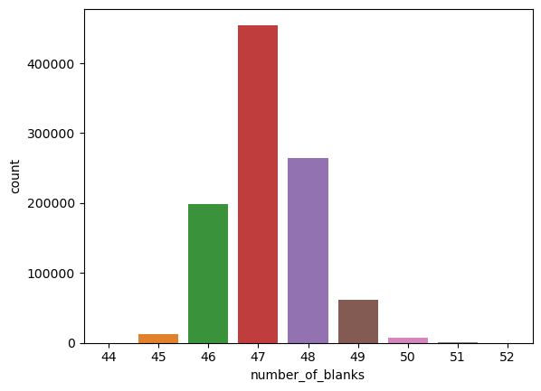

```python
sns.countplot(x=df['number_of_blanks'])
```

From the plot above, most of the puzzle has 47 blank grids.

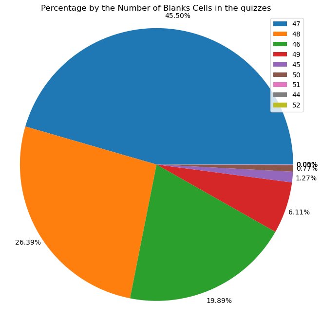

```python
fig1, ax1 = plt.subplots(figsize=(8, 8))
ax1.pie(df['number_of_blanks'].value_counts(), autopct='%1.2f%%', pctdistance=1.1)
ax1.legend(df['number_of_blanks'].value_counts().index)
ax1.axis('equal')  # Equal aspect ratio ensures that pie is drawn as a circle.

plt.title("Percentage by the Number of Blanks Cells in the quizzes")
plt.show()
```

From the pie chart above, we can see about 45.5% of quizzes with 47 blank cells. The medium difficulty level (46-49 blanks) is about 98% (45.50%+26.39%+19.89%+6.11%).

Before the model building, it is important to verify that all the solutions are valid sudoku solutions. A solution is valid must be validated with the following rules:

- Each row must contain 1 - 9 without repetition
- Each column must contain 1 - 9 without repetition
- Each of the nine 3 x 3 sub-squares must contain 1 - 9 without repetition

```python
import sudoku_check as sudoku_check
grid_0=np.array(list(map(int,list(df['solutions'][0])))).reshape(9,9)
sudoku_check.valid_board(grid_0)
```

```
True
```

```python
df['is_valid']=df.apply(lambda x: sudoku_check.valid_board(np.array(list(map(int,list(x['solutions'])))).reshape(9,9)), axis=1)
```

```python
df.head()
```

|  | quizzes | solutions | number_of_blanks | is_valid |
| --- | --- | --- | --- | --- |
| 0 | 0043002090050090010700600430060020871900074000... | 8643712593258497619712658434361925871986574322... | 46 | True |
| 1 | 0401000501070039605200080000000000170009068008... | 3461792581875239645296483719658324174729168358... | 47 | True |
| 2 | 6001203840084590720000060050002640300700800069... | 6951273841384596727248369158512647392739815469... | 47 | True |
| 3 | 4972000001004000050000160986203000403009000000... | 4972583161864397252537164986293815473759641828... | 48 | True |
| 4 | 0059103080094030600275001000300002010008200070... | 4659123781894735623275681497386452919548216372... | 49 | True |

```python
df['is_valid'].value_counts()
```

```
True    1000000
Name: is_valid, dtype: int64
```

All the solutions are vaild!

### Data Cleaning

Because we don't need the 'number_of_blanks' or 'is_valid' for deep learning model training; therefore, we may drop these two columns after the analysis.

```python
data = df.drop(['number_of_blanks','is_valid'], axis=1)
data.head()
```

|  | quizzes | solutions |
| --- | --- | --- |
| 0 | 0043002090050090010700600430060020871900074000... | 8643712593258497619712658434361925871986574322... |
| 1 | 0401000501070039605200080000000000170009068008... | 3461792581875239645296483719658324174729168358... |
| 2 | 6001203840084590720000060050002640300700800069... | 6951273841384596727248369158512647392739815469... |
| 3 | 4972000001004000050000160986203000403009000000... | 4972583161864397252537164986293815473759641828... |
| 4 | 0059103080094030600275001000300002010008200070... | 4659123781894735623275681497386452919548216372... |

### Preprocessing

Return to top

Before passing the data as inputs to the neural net model, use reshape function from NumPy to expand the dimensions (N, 9, 9, -1).

```python
X = np.array(df.quizzes.map(lambda x: list(map(int, x))).to_list()).reshape(-1,9,9,1)
Y = np.array(df.solutions.map(lambda x: list(map(int, x))).to_list()).reshape(-1,9,9)
```

```python
X.shape
```

```
(1000000, 9, 9, 1)
```

#### Normalization

Normalize the data by dividing it by 9 and subtracting it by 0.5 to achieve zero mean-centred data. Because the neural networks usually generate a better performance with zero-centred normalized data.

```python
# print the original first sudoku quiz
print(X[0].reshape(9,9))
```

```
[[0 0 4 3 0 0 2 0 9]
 [0 0 5 0 0 9 0 0 1]
 [0 7 0 0 6 0 0 4 3]
 [0 0 6 0 0 2 0 8 7]
 [1 9 0 0 0 7 4 0 0]
 [0 5 0 0 8 3 0 0 0]
 [6 0 0 0 0 0 1 0 5]
 [0 0 3 5 0 8 6 9 0]
 [0 4 2 9 1 0 3 0 0]]
```

```python
X = X / 9
```

```python
# print the first sudoku quiz to verify
print(X[0].reshape(9,9))
```

```
[[0.         0.         0.44444444 0.33333333 0.         0.
  0.22222222 0.         1.        ]
 [0.         0.         0.55555556 0.         0.         1.
  0.         0.         0.11111111]
 [0.         0.77777778 0.         0.         0.66666667 0.
  0.         0.44444444 0.33333333]
 [0.         0.         0.66666667 0.         0.         0.22222222
  0.         0.88888889 0.77777778]
 [0.11111111 1.         0.         0.         0.         0.77777778
  0.44444444 0.         0.        ]
 [0.         0.55555556 0.         0.         0.88888889 0.33333333
  0.         0.         0.        ]
 [0.66666667 0.         0.         0.         0.         0.
  0.11111111 0.         0.55555556]
 [0.         0.         0.33333333 0.55555556 0.         0.88888889
  0.66666667 1.         0.        ]
 [0.         0.44444444 0.22222222 1.         0.11111111 0.
  0.33333333 0.         0.        ]]
```

```python
X -= .5
```

```python
# print the first sudoku quiz to verify
print(X[0].reshape(9,9))
```

```
[[-0.5        -0.5        -0.05555556 -0.16666667 -0.5        -0.5
  -0.27777778 -0.5         0.5       ]
 [-0.5        -0.5         0.05555556 -0.5        -0.5         0.5
  -0.5        -0.5        -0.38888889]
 [-0.5         0.27777778 -0.5        -0.5         0.16666667 -0.5
  -0.5        -0.05555556 -0.16666667]
 [-0.5        -0.5         0.16666667 -0.5        -0.5        -0.27777778
  -0.5         0.38888889  0.27777778]
 [-0.38888889  0.5        -0.5        -0.5        -0.5         0.27777778
  -0.05555556 -0.5        -0.5       ]
 [-0.5         0.05555556 -0.5        -0.5         0.38888889 -0.16666667
  -0.5        -0.5        -0.5       ]
 [ 0.16666667 -0.5        -0.5        -0.5        -0.5        -0.5
  -0.38888889 -0.5         0.05555556]
 [-0.5        -0.5        -0.16666667  0.05555556 -0.5         0.38888889
   0.16666667  0.5        -0.5       ]
 [-0.5        -0.05555556 -0.27777778  0.5        -0.38888889 -0.5
  -0.16666667 -0.5        -0.5       ]]
```

Subtract 1 from the sudoku solution to reassign labels 0 ~ 8 to corresponding digits 1 ~ 9.

```python
# print the original first sudoku solution
print(Y[0].reshape(9,9))
```

```
[[8 6 4 3 7 1 2 5 9]
 [3 2 5 8 4 9 7 6 1]
 [9 7 1 2 6 5 8 4 3]
 [4 3 6 1 9 2 5 8 7]
 [1 9 8 6 5 7 4 3 2]
 [2 5 7 4 8 3 9 1 6]
 [6 8 9 7 3 4 1 2 5]
 [7 1 3 5 2 8 6 9 4]
 [5 4 2 9 1 6 3 7 8]]
```

```python
Y -= 1
```

```python
# print the first sudoku solution to verify
print(Y[0].reshape(9,9))
```

```
[[7 5 3 2 6 0 1 4 8]
 [2 1 4 7 3 8 6 5 0]
 [8 6 0 1 5 4 7 3 2]
 [3 2 5 0 8 1 4 7 6]
 [0 8 7 5 4 6 3 2 1]
 [1 4 6 3 7 2 8 0 5]
 [5 7 8 6 2 3 0 1 4]
 [6 0 2 4 1 7 5 8 3]
 [4 3 1 8 0 5 2 6 7]]
```

#### Data Splitting

Splitting data with a ratio of 80/20. The first 800,000 data (80%) as the training set and the last 200,000 data (20%) as the testing set.

```python
# set training split equal to 0.8
training_split = 0.8

splitidx = int(len(data) * training_split)
# first 80% of data as training set, last 20% of data as testing set
x_train, x_test = X[:splitidx], X[splitidx:]
y_train, y_test = Y[:splitidx], Y[splitidx:]
```

```python
# valify the size of training set
print(x_train.shape)
```

```
(800000, 9, 9, 1)
```

```python
# valify the size of testing set
print(x_test.shape)
```

```
(200000, 9, 9, 1)
```

### Neural Networks Models

Visualizing the Loss & Accuracy Plot of Training & Validation data can help us to know if a model has overfitting or underfitting. Matplotlib plots can help us visualize the history of network learning (accuracy & loss).

- If loss falls on the training set and increases on the testing set, the network model has overfitted.
- Training loss is much lower than validation loss, the network is overfitting.
- If the training loss is too high, it indicates the neural network model could not learn the training data and the network is underfitting.

```python
# define a plot function to plot the loss and accuracy of train and test
def loss_acc_plot(history):
    fig, ax = plt.subplots(1,2)
    fig.set_size_inches(12,6)

    ax[0].plot(history.history['loss'], label='train loss')
    ax[0].plot(history.history['val_loss'], label='val loss')
    ax[0].set_title('Training and Validation Loss')
    ax[0].set_ylabel('Loss')
    ax[0].set_xlabel('Epochs')
    ax[0].legend(['train', 'val'], loc='upper right')

    ax[1].plot(history.history['accuracy'], label='accuracy')
    ax[1].plot(history.history['val_accuracy'], label='val_accuracy')
    ax[1].set_title('Training and Validation Accuracy')
    ax[1].set_ylabel('Accuracy')
    ax[1].set_xlabel('Epochs')
    ax[1].legend(['train', 'val'], loc='upper right')

    plt.show()
```

The models use **Adam Optimizer** with a learning rate of **0.001**, the optimizer is save to a variable called optimizer.

```python
# using an Adam optimizer with a learning rate of 0.001
optimizer = tf.keras.optimizers.Adam(0.001)
```

Because we are training a **multiclass** classifier, predicting digits 1~9 (9 classes). Since we are not using one-hot encoded, the loss function that is using is **sparse_categorical_crossentropy**. For multi-class classification, **Softmax** will be the activation function for the last layer, which outputs multiple numerical numbers ranging from 0 to 8 (9 classes)corresponding to the probability of each class.

### Convolutional Neural Networks (CNNs)

Return to top

Convolutional neural networks (CNN) are good at extracting local features from the image and are commonly used to analyze visual imagery. If we treat each number as its own feature of the puzzle, so there are 81 different features available. CNN is good at extracting features, which could generate good performance.

**Hyperparameter Tuning**:

- **Number of epochs:** Increasing number of epochs can help improve the accuracy and lowers the loss; however, a high number of epochs may result in an overfitting model.
- **Number of layers:** Increasing number of layers help increases the accuracy; however, a high number of layers may result in an overfitting model.
- **Number of neurons per layer:** Increasing number of neurons can help imporve the accuracy.

#### CNN Model 1

Let's start with a simple CNN model.

- The model start with a **Conv2D()** class, which is a 2D convolution layer. The first layer is a convolution layer with 64 kernels that are (3,3) in dimension. The padding is 'same' so that a padding gets the same output dimension as the input. The ReLU is used as the activation function. The input are batches of arrays of shape (9,9).
- **Batch normalization** is a method to normalize the inputs of each layer. It can help speed up and stabilize neural networks.
- Adding a convolution layer with 64 kernels of shape (3 x 3), a batch normalization layer and a convolution layer with 128 kernels of shape (1 x 1).
- After that, a **Flatten** layer help to comprise the (9,9, 128) to 10,368 (9x9x128) input nodes.
- **Dense** is a regular neural network layer that performs a dot product operation. The matrix multiplication is represented by the dot(X, W) + B, where X is the input to the layer, W is the weight, and B is the bias. Using 729 (81x9) in the dense layer means performing matrix multiplication to result in an output matrix with a desired last dimension to be 729.
- **LayerNormalization** is used to normalize a layer.
- Using **Reshape** layer to (9,9,9) so that the last layer has 9 neurons corresponding to the 9 classes(0~8) with a **softmax activation function**.

```python
# Function for the cnn model function
def cnn_model_func1():
    # Instantiate model
    model = tf.keras.Sequential()
    # add a convolution layer with 64 kernels of shape (3 x 3)
    model.add(Conv2D(64, kernel_size=(3,3), activation='relu', padding='same', input_shape=(9,9,1)))
    # normalize the kernel values for Convolution Layers
    model.add(BatchNormalization())
    # add a convolution layer with 64 kernels of shape (3 x 3)
    model.add(Conv2D(64, kernel_size=(3,3), activation='relu', padding='same'))
    # normalize the kernel values for Convolution Layers
    model.add(BatchNormalization())
    # add a convolution layer with 128 kernels of shape (1 x 1)
    model.add(Conv2D(128, kernel_size=(1,1), activation='relu', padding='same'))
    # comprises the (9,9, 128) to a 10,368 (9*9*128) input nodes
    model.add(Flatten())
    # Add a dense layer to perform matrix multiplication to result in an output matix with 729(81*9)
    model.add(Dense(81*9))
    # normalize the dense layer above
    model.add(LayerNormalization(axis=-1))
    # the last layer has 9 neurons corresponding to the 9 classes with a softmax activation function
    model.add(Reshape((9, 9, 9)))
    # using softmax as activation function for multiclass
    model.add(Activation('softmax'))

    return model
```

```python
# Initialise the cnn model
cnn_model1 = cnn_model_func1()
# print summary of the cnn model
cnn_model1.summary()
```

```
Model: "sequential"
_________________________________________________________________
 Layer (type)                Output Shape              Param #
=================================================================
 conv2d (Conv2D)             (None, 9, 9, 64)          640

 batch_normalization (BatchN  (None, 9, 9, 64)         256
 ormalization)

 conv2d_1 (Conv2D)           (None, 9, 9, 64)          36928

 batch_normalization_1 (Batc  (None, 9, 9, 64)         256
 hNormalization)

 conv2d_2 (Conv2D)           (None, 9, 9, 128)         8320

 flatten (Flatten)           (None, 10368)             0

 dense (Dense)               (None, 729)               7559001

 layer_normalization (LayerN  (None, 729)              1458
 ormalization)

 reshape (Reshape)           (None, 9, 9, 9)           0

 activation (Activation)     (None, 9, 9, 9)           0

=================================================================
Total params: 7,606,859
Trainable params: 7,606,603
Non-trainable params: 256
_________________________________________________________________
```

The model compile with the **sparse_categorical_crossentropy** loss function which does not require passing one-hot vectors as output. Training with a **batch size of 32 and epochs of 5**. Batch size is the number of samples processed before the network model is updated. Large batch size may result in overfitting so the model starts with 32. Let's train it with five epochs to see how it performs.

```python
# Train the model
cnn_model1.compile(loss='sparse_categorical_crossentropy', optimizer=optimizer, metrics=['accuracy'])

history1 = cnn_model1.fit(x_train, y_train, batch_size=32, epochs=5, validation_data=(x_test, y_test))
```

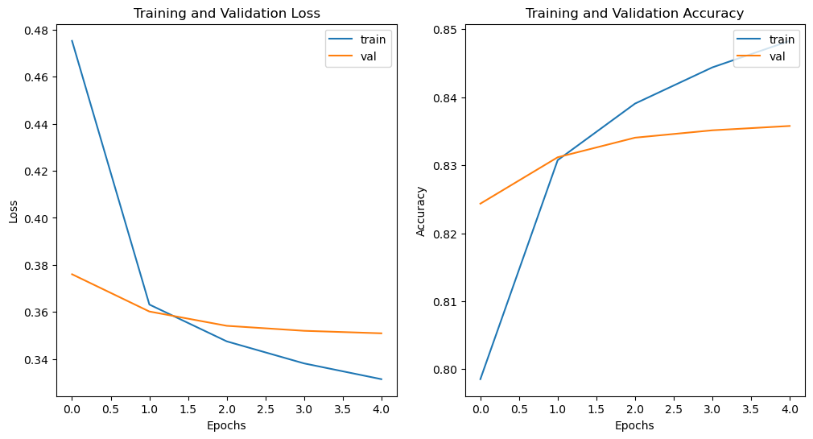

```python
loss_acc_plot(history1)
```

```python
training_accuracy1 = history1.history['accuracy'][-1]
training_loss1 = history1.history['loss'][-1]
print(f"Training Loss: {training_loss1:.4f}, Training Accuracy: {training_accuracy1:.4f}")
```

```
Training Loss: 0.3314, Training Accuracy: 0.8483
```

```python
val_loss1, val_accuracy1 = cnn_model1.evaluate(x_test,y_test)
print(f"Done!\nValiation Loss: {val_loss1:.4f}, Validation Accuracy: {val_accuracy1:.4f}")
```

```
Done!
Valiation Loss: 0.3509, Validation Accuracy: 0.8358
```

The training accuracy of 0.8483 is not bad. But let's test the model to see if it can solve a real sudoku game or not.

```python
train_pred_1 = cnn_model1.predict(x_train[0].reshape((9, 9)).reshape(1, 9, 9, 1)).argmax(-1)+1
train_pred_1
```

```
array([[[8, 6, 4, 3, 7, 5, 2, 6, 9],
        [3, 3, 5, 4, 4, 9, 7, 7, 1],
        [9, 7, 1, 2, 6, 5, 5, 4, 3],
        [4, 3, 6, 1, 5, 2, 9, 8, 7],
        [1, 9, 8, 6, 5, 7, 4, 3, 6],
        [4, 5, 7, 6, 8, 3, 9, 1, 6],
        [6, 8, 9, 7, 3, 4, 1, 2, 5],
        [7, 1, 3, 5, 2, 8, 6, 9, 4],
        [5, 4, 2, 9, 1, 6, 3, 7, 8]]], dtype=int64)
```

```python
train_real_1 = y_train[0]+1
train_real_1
```

```
array([[8, 6, 4, 3, 7, 1, 2, 5, 9],
       [3, 2, 5, 8, 4, 9, 7, 6, 1],
       [9, 7, 1, 2, 6, 5, 8, 4, 3],
       [4, 3, 6, 1, 9, 2, 5, 8, 7],
       [1, 9, 8, 6, 5, 7, 4, 3, 2],
       [2, 5, 7, 4, 8, 3, 9, 1, 6],
       [6, 8, 9, 7, 3, 4, 1, 2, 5],
       [7, 1, 3, 5, 2, 8, 6, 9, 4],
       [5, 4, 2, 9, 1, 6, 3, 7, 8]])
```

```python
train_pred_1 - train_real_1
```

```
array([[[ 0,  0,  0,  0,  0,  4,  0,  1,  0],
        [ 0,  1,  0, -4,  0,  0,  0,  1,  0],
        [ 0,  0,  0,  0,  0,  0, -3,  0,  0],
        [ 0,  0,  0,  0, -4,  0,  4,  0,  0],
        [ 0,  0,  0,  0,  0,  0,  0,  0,  4],
        [ 2,  0,  0,  2,  0,  0,  0,  0,  0],
        [ 0,  0,  0,  0,  0,  0,  0,  0,  0],
        [ 0,  0,  0,  0,  0,  0,  0,  0,  0],
        [ 0,  0,  0,  0,  0,  0,  0,  0,  0]]], dtype=int64)
```

From above, we can see the model is making some bad prediction with the first training quiz.

```python
test_pred_1 = cnn_model1.predict(x_test[1].reshape((9, 9)).reshape(1, 9, 9, 1)).argmax(-1)+1
test_pred_1
```

```
array([[[3, 1, 6, 4, 9, 2, 7, 6, 7],
        [7, 9, 7, 5, 1, 8, 2, 4, 3],
        [2, 5, 4, 3, 7, 6, 2, 8, 1],
        [8, 2, 9, 6, 4, 1, 5, 3, 7],
        [6, 7, 3, 2, 8, 5, 4, 9, 4],
        [5, 4, 9, 7, 3, 9, 6, 2, 8],
        [4, 3, 2, 8, 5, 7, 9, 1, 6],
        [1, 6, 6, 6, 6, 3, 8, 7, 4],
        [9, 8, 6, 1, 6, 7, 8, 5, 2]]], dtype=int64)
```

```python
test_real_1 = y_test[1]+1
test_real_1
```

```
array([[3, 1, 8, 4, 9, 2, 7, 6, 5],
       [7, 9, 6, 5, 1, 8, 2, 4, 3],
       [2, 5, 4, 3, 7, 6, 1, 8, 9],
       [8, 2, 9, 6, 4, 1, 5, 3, 7],
       [6, 7, 3, 2, 8, 5, 4, 9, 1],
       [5, 4, 1, 7, 3, 9, 6, 2, 8],
       [4, 3, 2, 8, 5, 7, 9, 1, 6],
       [1, 6, 5, 9, 2, 3, 8, 7, 4],
       [9, 8, 7, 1, 6, 4, 3, 5, 2]])
```

```python
test_pred_1 - test_real_1
```

```
array([[[ 0,  0, -2,  0,  0,  0,  0,  0,  2],
        [ 0,  0,  1,  0,  0,  0,  0,  0,  0],
        [ 0,  0,  0,  0,  0,  0,  1,  0, -8],
        [ 0,  0,  0,  0,  0,  0,  0,  0,  0],
        [ 0,  0,  0,  0,  0,  0,  0,  0,  3],
        [ 0,  0,  8,  0,  0,  0,  0,  0,  0],
        [ 0,  0,  0,  0,  0,  0,  0,  0,  0],
        [ 0,  0,  1, -3,  4,  0,  0,  0,  0],
        [ 0,  0, -1,  0,  0,  3,  5,  0,  0]]], dtype=int64)
```

We can see it is making bad prediction on some number on the second testing quiz.

CNN Model 1 only achieved an accuracy of 84% on the training set and is not ideal fro solving a sudoku game since it is making bad prediction on the real sudoku game. Let's see if we can create a better model for solving sudoku game.

#### CNN Model 2

Return to top

Let's try with another simple CNN model.

- The model start with a **Conv2D()** class, which is a 2D convolution layer. The first layer is a convolution layer with 64 kernels that are (3,3) in dimension. The padding is 'same' so that a padding gets the same output dimension as the input. The ReLU is used as the activation function.
- After that, a **Flatten** layer help to comprise the (9,9, 64) to 5,184 (9x9x64) input nodes.
- Add a **Dense** layer that performs a dot product operation. Using 2187 (81x9x3) in the dense layer means performing matrix multiplication to result in an output matrix with a desired last dimension to be 2187.
- Add a **Dense** layer that performs a dot product operation. Using 1458 (81x9x2) in the dense layer means performing matrix multiplication to result in an output matrix with a desired last dimension to be 1458.
- A **Dropout** of 20% is added to the hidden layer. A dropout method randomly deactivated a certain number of neurons during the training process. Adding a dropout of 20% means 20% of the neurons in that layer will be randomly deactivated during training.
- Add a **Dense** layer that performs a dot product operation. Using 729 (81x9) in the dense layer means performing matrix multiplication to result in an output matrix with a desired last dimension to be 729.
- **LayerNormalization** is used to normalize a layer.
- Using **Reshape** layer to (9,9,9) so that the last layer has 9 neurons corresponding to the 9 classes(0~8) with a **softmax activation function**.

```python
def cnn_model_func2():
    # Instantiate model
    model = tf.keras.Sequential()
    # add a convolutiion layer with 64 kernels of shape (3 x 3)
    model.add(Conv2D(64, kernel_size=(3,3), activation='relu', padding='same', input_shape=(9,9,1)))
    # comprise the (9 , 9 , 64) to 5184 input nodes
    model.add(Flatten())
    # add a dense layer (81 * 9 *3)
    model.add(Dense(81*9*3, activation='relu'))
     # add a dense layer (81 * 9 *2)
    model.add(Dense(81*9*2, activation='relu'))
    # add a dropout layer of 20% to prevent overfitting
    model.add(Dropout(.20))
     # add a dense layer (81 * 9 )
    model.add(Dense(81*9, activation='relu'))
    # normalize the dense layer
    model.add(LayerNormalization(axis=-1))
    # reshape and using softmax as activation function for multiclass
    model.add(Reshape((9, 9, 9)))
    model.add(Activation('softmax'))

    return model
```

```python
# Initialise the cnn model
cnn_model2 = cnn_model_func2()
# print summary of the cnn model
cnn_model2.summary()
```

```
Model: "sequential_3"
_________________________________________________________________
 Layer (type)                Output Shape              Param #
=================================================================
 conv2d_5 (Conv2D)           (None, 9, 9, 64)          640

 flatten_3 (Flatten)         (None, 5184)              0

 dense_7 (Dense)             (None, 2187)              11339595

 dense_8 (Dense)             (None, 1458)              3190104

 dropout_4 (Dropout)         (None, 1458)              0

 dense_9 (Dense)             (None, 729)               1063611

 layer_normalization_3 (Laye  (None, 729)              1458
 rNormalization)

 reshape_3 (Reshape)         (None, 9, 9, 9)           0

 activation_3 (Activation)   (None, 9, 9, 9)           0

=================================================================
Total params: 15,595,408
Trainable params: 15,595,408
Non-trainable params: 0
_________________________________________________________________
```

```python
# Train the model
cnn_model2.compile(loss='sparse_categorical_crossentropy', optimizer=optimizer, metrics=['accuracy'])

history2 = cnn_model2.fit(x_train, y_train, batch_size=32, epochs=100, validation_data=(x_test, y_test))
```

[figure not shown]

```python
loss_acc_plot(history2)
```

```python
training_accuracy2 = history2.history['accuracy'][-1]
training_loss2 = history2.history['loss'][-1]
print(f"Training Loss: {training_loss2:.4f}, Training Accuracy: {training_accuracy2:.4f}")
```

```
Training Loss: 1.8927, Training Accuracy: 0.2503
```

```python
val_loss2, val_accuracy2 = cnn_model2.evaluate(x_test,y_test)
print(f"Done!\nValiation Loss: {val_loss2:.4f}, Validation Accuracy: {val_accuracy2:.4f}")
```

```
Done!
Valiation Loss: 1.8568, Validation Accuracy: 0.2627
```

After 100 epochs, the training accuracy is only 0.2503. The model takes a longer time to train and the prediction is low. The model is underfitting.

#### CNN Model 3

Return to top

Let's build on top of the CNN Model 1 with **MaxPooling**.

**Pooling layers** can help to reduce the dimensions of the feature maps of convolution. It can help the model focus only on the detected pattern. **Max Pooling** will find the maximum values at a specific area of the feature map. Adding pooling layers can help speed up the training time and reduce overfitting issues.

The model is using **MaxPooling2d** with (3,3) since it makes sense with a 9 X 9 sudoku board game.

```python
def cnn_model_func3():

    model = tf.keras.Sequential()
    model.add(Conv2D(64, kernel_size=(3,3), activation='relu', padding='same', input_shape=(9,9,1)))
    model.add(BatchNormalization())
    model.add(Conv2D(64, kernel_size=(3,3), activation='relu', padding='same'))
    model.add(BatchNormalization())
    model.add(Conv2D(128, kernel_size=(1,1), activation='relu', padding='same'))

    # adding MaxPooling layer
    model.add(MaxPooling2D(3,3))

    model.add(Flatten())
    model.add(Dense(81*9))
    model.add(tf.keras.layers.LayerNormalization(axis=-1))
    model.add(Reshape((9, 9, 9)))
    model.add(Activation('softmax'))

    return model
```

```python
# Initialise the cnn model
cnn_model3 = cnn_model_func3()
# print summary of the cnn model
cnn_model3.summary()
```

```
Model: "sequential_4"
_________________________________________________________________
 Layer (type)                Output Shape              Param #
=================================================================
 conv2d_6 (Conv2D)           (None, 9, 9, 64)          640

 batch_normalization_2 (Batc  (None, 9, 9, 64)         256
 hNormalization)

 conv2d_7 (Conv2D)           (None, 9, 9, 64)          36928

 batch_normalization_3 (Batc  (None, 9, 9, 64)         256
 hNormalization)

 conv2d_8 (Conv2D)           (None, 9, 9, 128)         8320

 max_pooling2d (MaxPooling2D  (None, 3, 3, 128)        0
 )

 flatten_4 (Flatten)         (None, 1152)              0

 dense_10 (Dense)            (None, 729)               840537

 layer_normalization_4 (Laye  (None, 729)              1458
 rNormalization)

 reshape_4 (Reshape)         (None, 9, 9, 9)           0

 activation_4 (Activation)   (None, 9, 9, 9)           0

=================================================================
Total params: 888,395
Trainable params: 888,139
Non-trainable params: 256
_________________________________________________________________
```

```python
# Train the model
cnn_model3.compile(loss='sparse_categorical_crossentropy', optimizer=optimizer, metrics=['accuracy'])

history3 = cnn_model3.fit(x_train, y_train, batch_size=64, epochs=30, validation_data=(x_test, y_test))
```

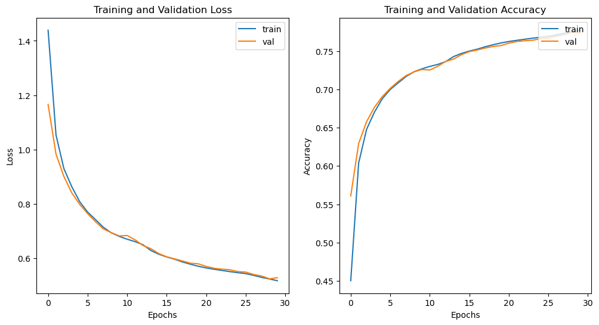

```python
loss_acc_plot(history3)
```

```python
training_accuracy3 = history3.history['accuracy'][-1]
training_loss3 = history3.history['loss'][-1]
print(f"Training Loss: {training_loss3:.4f}, Training Accuracy: {training_accuracy3:.4f}")
```

```
Training Loss: 0.5169, Training Accuracy: 0.7771
```

```python
val_loss3, val_accuracy3 = cnn_model3.evaluate(x_test,y_test)
print(f"Done!\nValiation Loss: {val_loss3:.4f}, Validation Accuracy: {val_accuracy3:.4f}")
```

```
Done!
Valiation Loss: 0.5279, Validation Accuracy: 0.7735
```

After 30 epochs, the model has a training accuracy of 0.7771. The training accuracy is still low.

#### CNN Model 4

Return to top

Let's build on top of the CNN Model 1 with **strides of (3x3)**. Considering a valid Sudoku solution must follow each of the nine 3 X 3 sub-squares must contain 1 - 9 without repetition.

**Stride** defines how many steps we are moving in each step in convolution. Using a stride of (3,3) means the convolution moving each of the nine 3 x 3 sub-squares.

```python
# Function for the cnn model function
def cnn_model_func4():

    model = tf.keras.Sequential()
     # add a convolution layer with 64 kernels of shape (3 x 3), strides (3,3)
    model.add(Conv2D(64, kernel_size=(3,3), strides=(3,3), activation='relu', padding='same', input_shape=(9,9,1)))
    model.add(BatchNormalization())
    model.add(Conv2D(64, kernel_size=(3,3), strides=(3,3), activation='relu', padding='same'))
    model.add(BatchNormalization())
    model.add(Conv2D(128, kernel_size=(1,1), strides=(3,3), activation='relu', padding='same'))

    model.add(Flatten())
    model.add(Dense(81*9))
    # add a dropout layer of 10% to prevent overfitting
    model.add(Dropout(.10))
    model.add(tf.keras.layers.LayerNormalization(axis=-1))
    model.add(Reshape((9, 9, 9)))
    model.add(Activation('softmax'))

    return model
```

```python
# Initialise the cnn model
cnn_model4 = cnn_model_func4()
# print summary of the cnn model
cnn_model4.summary()
```

```
Model: "sequential_9"
_________________________________________________________________
 Layer (type)                Output Shape              Param #
=================================================================
 conv2d_21 (Conv2D)          (None, 3, 3, 64)          640

 batch_normalization_12 (Bat  (None, 3, 3, 64)         256
 chNormalization)

 conv2d_22 (Conv2D)          (None, 1, 1, 64)          36928

 batch_normalization_13 (Bat  (None, 1, 1, 64)         256
 chNormalization)

 conv2d_23 (Conv2D)          (None, 1, 1, 128)         8320

 flatten_9 (Flatten)         (None, 128)               0

 dense_15 (Dense)            (None, 729)               94041

 dropout_8 (Dropout)         (None, 729)               0

 layer_normalization_9 (Laye  (None, 729)              1458
 rNormalization)

 reshape_9 (Reshape)         (None, 9, 9, 9)           0

 activation_9 (Activation)   (None, 9, 9, 9)           0

=================================================================
Total params: 141,899
Trainable params: 141,643
Non-trainable params: 256
_________________________________________________________________
```

```python
# Train the model
cnn_model4.compile(loss='sparse_categorical_crossentropy', optimizer=optimizer, metrics=['accuracy'])

history4 = cnn_model4.fit(x_train, y_train, batch_size=32, epochs=100, validation_data=(x_test, y_test))
```

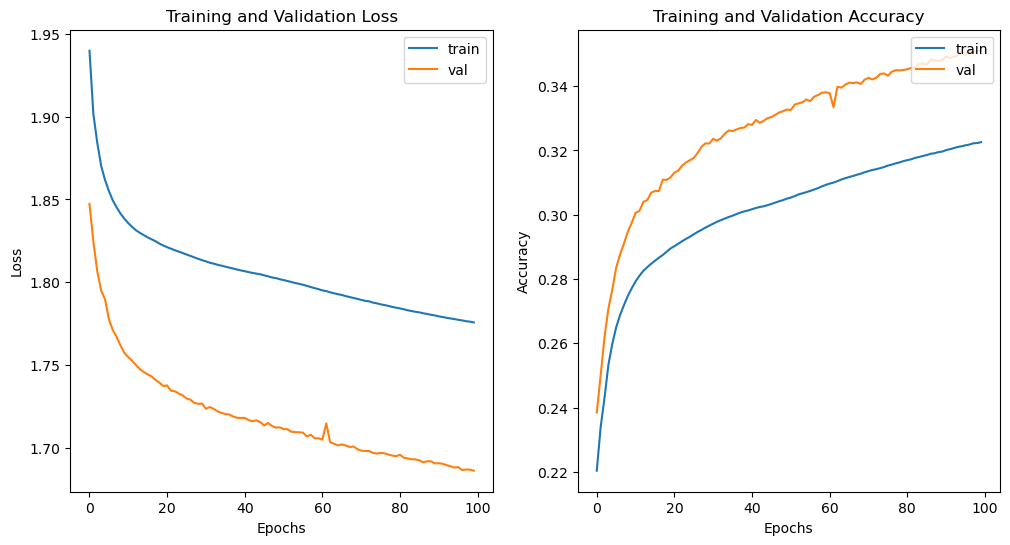

```python
loss_acc_plot(history4)
```

```python
training_accuracy4 = history4.history['accuracy'][-1]
training_loss4 = history4.history['loss'][-1]
print(f"Training Loss: {training_loss4:.4f}, Training Accuracy: {training_accuracy4:.4f}")
```

```
Training Loss: 1.7757, Training Accuracy: 0.3226
```

```python
val_loss4, val_accuracy4 = cnn_model4.evaluate(x_test,y_test)
print(f"Done!\nValiation Loss: {val_loss4:.4f}, Validation Accuracy: {val_accuracy4:.4f}")
```

```
Done!
Valiation Loss: 1.6860, Validation Accuracy: 0.3510
```

#### CNN Model 5

Return to top

Let's add more layers and increase the number of neurons to see if the model performs better.

```python
# Function for the cnn model function
def cnn_model_func5():

    model = tf.keras.Sequential()

    model.add(Conv2D(64, kernel_size=(3,3), activation='relu', padding='same', input_shape=(9,9,1)))
    model.add(BatchNormalization())
    model.add(Conv2D(64, kernel_size=(3,3), activation='relu', padding='same'))
    model.add(BatchNormalization())
    model.add(Conv2D(128, kernel_size=(3,3), activation='relu', padding='same'))
    model.add(BatchNormalization())
    model.add(Conv2D(256, kernel_size=(3,3), activation='relu', padding='same'))
    model.add(BatchNormalization())
    model.add(Conv2D(512, kernel_size=(3,3), activation='relu', padding='same'))
    model.add(BatchNormalization())
    model.add(Conv2D(1024, kernel_size=(3,3), activation='relu', padding='same'))

    model.add(Flatten())
    model.add(Dense(81*9))
    # add a dropout layer of 10% to prevent overfitting
    model.add(Dropout(.1))
    model.add(tf.keras.layers.LayerNormalization(axis=-1))
    model.add(Reshape((9, 9, 9)))
    model.add(Activation('softmax'))

    return model
```

```python
# Initialise the cnn model
cnn_model5 = cnn_model_func5()
# print summary of the cnn model
cnn_model5.summary()
```

```
Model: "sequential_10"
_________________________________________________________________
 Layer (type)                Output Shape              Param #
=================================================================
 conv2d_24 (Conv2D)          (None, 9, 9, 64)          640

 batch_normalization_14 (Bat  (None, 9, 9, 64)         256
 chNormalization)

 conv2d_25 (Conv2D)          (None, 9, 9, 64)          36928

 batch_normalization_15 (Bat  (None, 9, 9, 64)         256
 chNormalization)

 conv2d_26 (Conv2D)          (None, 9, 9, 128)         73856

 batch_normalization_16 (Bat  (None, 9, 9, 128)        512
 chNormalization)

 conv2d_27 (Conv2D)          (None, 9, 9, 256)         295168

 batch_normalization_17 (Bat  (None, 9, 9, 256)        1024
 chNormalization)

 conv2d_28 (Conv2D)          (None, 9, 9, 512)         1180160

 batch_normalization_18 (Bat  (None, 9, 9, 512)        2048
 chNormalization)

 conv2d_29 (Conv2D)          (None, 9, 9, 1024)        4719616

 flatten_10 (Flatten)        (None, 82944)             0

 dense_16 (Dense)            (None, 729)               60466905

 dropout_9 (Dropout)         (None, 729)               0

 layer_normalization_10 (Lay  (None, 729)              1458
 erNormalization)

 reshape_10 (Reshape)        (None, 9, 9, 9)           0

 activation_10 (Activation)  (None, 9, 9, 9)           0

=================================================================
Total params: 66,778,827
Trainable params: 66,776,779
Non-trainable params: 2,048
_________________________________________________________________
```

```python
# Train the model
cnn_model5.compile(loss='sparse_categorical_crossentropy', optimizer=optimizer, metrics=['accuracy'])

history5 = cnn_model5.fit(x_train, y_train, batch_size=64, epochs=8, validation_data=(x_test, y_test))
```

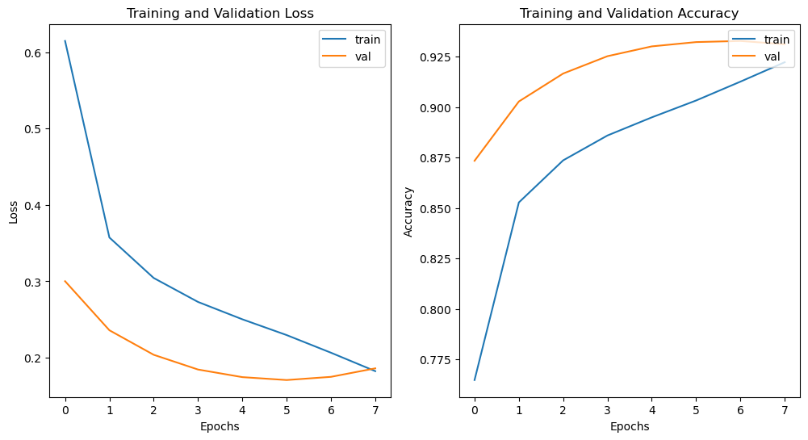

```python
loss_acc_plot(history5)
```

```python
training_accuracy5 = history5.history['accuracy'][-1]
training_loss5 = history5.history['loss'][-1]
print(f"Training Loss: {training_loss5:.4f}, Training Accuracy: {training_accuracy5:.4f}")
```

```
Training Loss: 0.1824, Training Accuracy: 0.9223
```

```python
val_loss5, val_accuracy5 = cnn_model5.evaluate(x_test,y_test)
print(f"Done!\nValiation Loss: {val_loss5:.4f}, Validation Accuracy: {val_accuracy5:.4f}")
```

```
Done!
Valiation Loss: 0.1861, Validation Accuracy: 0.9312
```

After 8 epochs, the training accuracy is 0.9223 and the validation accuracy is 0.9312. This is a high accuracy; however, if we check the graph that compared the training and validation loss, we can see that the model is overfitting after five epochs since the validation loss is increasing but the training loss is still decreasing.

#### CNN Model 6

Return to top

Adding strides of (3x3) to see how it performs.

```python
# Function for the cnn model function
def cnn_model_func6():

    model = tf.keras.Sequential()

    model.add(Conv2D(32, kernel_size=(3,3), strides=(3,3), activation='relu', padding='same', input_shape=(9,9,1)))
    model.add(BatchNormalization())
    model.add(Conv2D(64, kernel_size=(3,3), strides=(3,3), activation='relu', padding='same'))
    model.add(BatchNormalization())
    model.add(Conv2D(128, kernel_size=(3,3), strides=(3,3), activation='relu', padding='same'))
    model.add(BatchNormalization())
    model.add(Conv2D(256, kernel_size=(3,3), strides=(3,3), activation='relu', padding='same'))
    model.add(BatchNormalization())
    model.add(Conv2D(512, kernel_size=(3,3), strides=(3,3), activation='relu', padding='same'))
    model.add(BatchNormalization())
    model.add(Conv2D(1024, kernel_size=(3,3), strides=(3,3), activation='relu', padding='same'))
    model.add(Flatten())
    model.add(Dense(512,activation='relu'))
    model.add(Dropout(0.1))
    model.add(Dense(81*9))
    model.add(tf.keras.layers.LayerNormalization(axis=-1))
    model.add(Reshape((9, 9, 9)))
    model.add(Activation('softmax'))

    return model
```

```python
# Initialise the cnn model
cnn_model6 = cnn_model_func6()
# print summary of the cnn model
cnn_model6.summary()
```

```
Model: "sequential_11"
_________________________________________________________________
 Layer (type)                Output Shape              Param #
=================================================================
 conv2d_30 (Conv2D)          (None, 3, 3, 32)          320

 batch_normalization_19 (Bat  (None, 3, 3, 32)         128
 chNormalization)

 conv2d_31 (Conv2D)          (None, 1, 1, 64)          18496

 batch_normalization_20 (Bat  (None, 1, 1, 64)         256
 chNormalization)

 conv2d_32 (Conv2D)          (None, 1, 1, 128)         73856

 batch_normalization_21 (Bat  (None, 1, 1, 128)        512
 chNormalization)

 conv2d_33 (Conv2D)          (None, 1, 1, 256)         295168

 batch_normalization_22 (Bat  (None, 1, 1, 256)        1024
 chNormalization)

 conv2d_34 (Conv2D)          (None, 1, 1, 512)         1180160

 batch_normalization_23 (Bat  (None, 1, 1, 512)        2048
 chNormalization)

 conv2d_35 (Conv2D)          (None, 1, 1, 1024)        4719616

 flatten_11 (Flatten)        (None, 1024)              0

 dense_17 (Dense)            (None, 512)               524800

 dropout_10 (Dropout)        (None, 512)               0

 dense_18 (Dense)            (None, 729)               373977

 layer_normalization_11 (Lay  (None, 729)              1458
 erNormalization)

 reshape_11 (Reshape)        (None, 9, 9, 9)           0

 activation_11 (Activation)  (None, 9, 9, 9)           0

=================================================================
Total params: 7,191,819
Trainable params: 7,189,835
Non-trainable params: 1,984
_________________________________________________________________
```

```python
# Train the model
cnn_model6.compile(loss='sparse_categorical_crossentropy', optimizer=optimizer, metrics=['accuracy'])

history6 = cnn_model6.fit(x_train, y_train, batch_size=64, epochs=100, validation_data=(x_test, y_test))
```

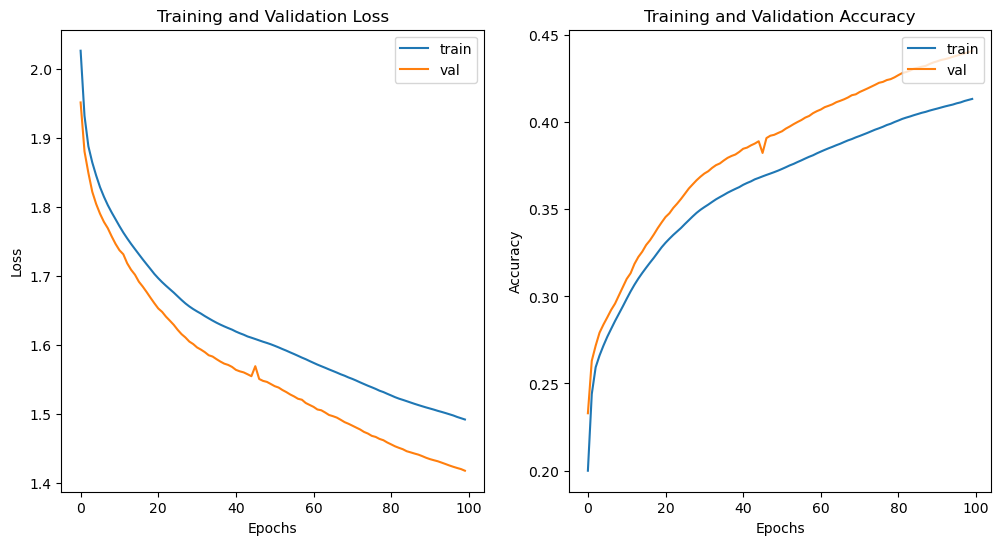

```python
loss_acc_plot(history6)
```

```python
training_accuracy6 = history6.history['accuracy'][-1]
training_loss6 = history6.history['loss'][-1]
print(f"Training Loss: {training_loss6:.4f}, Training Accuracy: {training_accuracy6:.4f}")
```

```
Training Loss: 1.4924, Training Accuracy: 0.4133
```

```python
val_loss6, val_accuracy6 = cnn_model6.evaluate(x_test,y_test)
print(f"Done!\nValiation Loss: {val_loss6:.4f}, Validation Accuracy: {val_accuracy6:.4f}")
```

```
Done!
Valiation Loss: 1.4183, Validation Accuracy: 0.4410
```

After 100 epochs, the training accuracy is only 41.33%. The model is underfitting.

#### CNN Model 7

Return to top

Testing model with strides of (2x2).

```python
def cnn_model_func7():

    model = tf.keras.Sequential()

    model.add(Conv2D(32, kernel_size=(3,3), strides=(2,2), activation='relu', padding='same', input_shape=(9,9,1)))
    model.add(BatchNormalization())
    model.add(Conv2D(64, kernel_size=(3,3), strides=(2,2), activation='relu', padding='same'))
    model.add(BatchNormalization())
    model.add(Conv2D(128, kernel_size=(3,3), strides=(2,2), activation='relu', padding='same'))
    model.add(BatchNormalization())
    model.add(Conv2D(256, kernel_size=(3,3), strides=(2,2), activation='relu', padding='same'))
    model.add(BatchNormalization())
    model.add(Conv2D(512, kernel_size=(3,3), strides=(2,2), activation='relu', padding='same'))
    model.add(BatchNormalization())
    model.add(Conv2D(1024, kernel_size=(3,3), strides=(2,2), activation='relu', padding='same'))
    model.add(Flatten())
    model.add(Dense(512,activation='relu'))
    model.add(Dropout(0.1))
    model.add(Dense(81*9))
    model.add(tf.keras.layers.LayerNormalization(axis=-1))
    model.add(Reshape((9, 9, 9)))
    model.add(Activation('softmax'))

    return model
```

```python
# Initialise the cnn model
cnn_model7 = cnn_model_func7()
# print summary of the cnn model
cnn_model7.summary()
```

```
Model: "sequential_12"
_________________________________________________________________
 Layer (type)                Output Shape              Param #
=================================================================
 conv2d_36 (Conv2D)          (None, 5, 5, 32)          320

 batch_normalization_24 (Bat  (None, 5, 5, 32)         128
 chNormalization)

 conv2d_37 (Conv2D)          (None, 3, 3, 64)          18496

 batch_normalization_25 (Bat  (None, 3, 3, 64)         256
 chNormalization)

 conv2d_38 (Conv2D)          (None, 2, 2, 128)         73856

 batch_normalization_26 (Bat  (None, 2, 2, 128)        512
 chNormalization)

 conv2d_39 (Conv2D)          (None, 1, 1, 256)         295168

 batch_normalization_27 (Bat  (None, 1, 1, 256)        1024
 chNormalization)

 conv2d_40 (Conv2D)          (None, 1, 1, 512)         1180160

 batch_normalization_28 (Bat  (None, 1, 1, 512)        2048
 chNormalization)

 conv2d_41 (Conv2D)          (None, 1, 1, 1024)        4719616

 flatten_12 (Flatten)        (None, 1024)              0

 dense_19 (Dense)            (None, 512)               524800

 dropout_11 (Dropout)        (None, 512)               0

 dense_20 (Dense)            (None, 729)               373977

 layer_normalization_12 (Lay  (None, 729)              1458
 erNormalization)

 reshape_12 (Reshape)        (None, 9, 9, 9)           0

 activation_12 (Activation)  (None, 9, 9, 9)           0

=================================================================
Total params: 7,191,819
Trainable params: 7,189,835
Non-trainable params: 1,984
_________________________________________________________________
```

```python
# Train the model
cnn_model7.compile(loss='sparse_categorical_crossentropy', optimizer=optimizer, metrics=['accuracy'])

history7 = cnn_model7.fit(x_train, y_train, batch_size=64, epochs=100, validation_data=(x_test, y_test))
```

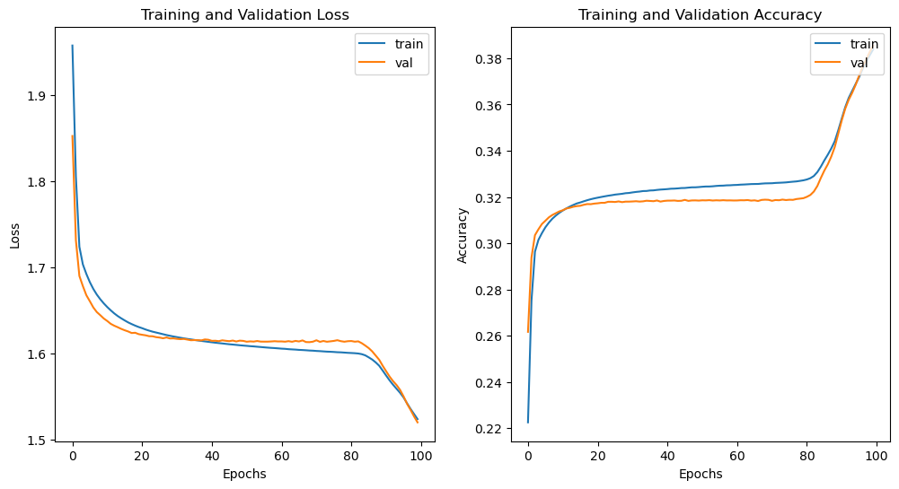

```python
loss_acc_plot(history7)
```

```python
training_accuracy7 = history7.history['accuracy'][-1]
training_loss7 = history7.history['loss'][-1]
print(f"Training Loss: {training_loss7:.4f}, Training Accuracy: {training_accuracy7:.4f}")
```

```
Training Loss: 1.5239, Training Accuracy: 0.3838
```

```python
val_loss7, val_accuracy7 = cnn_model7.evaluate(x_test,y_test)
print(f"Done!\nValiation Loss: {val_loss7:.4f}, Validation Accuracy: {val_accuracy7:.4f}")
```

```
Done!
Valiation Loss: 1.5201, Validation Accuracy: 0.3855
```

The training accuracy is 0.3838, using strides (2X2) is not preferable.

#### CNN Model 8

Return to top

Using 6 convolution layers with 512 kernels to see if the model performance has improved.

```python
# Function for the cnn model function
def cnn_model_func8():

    model = tf.keras.Sequential()

    model.add(Conv2D(512, kernel_size=(3,3), activation='relu', padding='same', input_shape=(9,9,1)))
    model.add(BatchNormalization())
    model.add(Conv2D(512, kernel_size=(3,3), activation='relu', padding='same'))
    model.add(BatchNormalization())
    model.add(Conv2D(512, kernel_size=(3,3), activation='relu', padding='same'))
    model.add(BatchNormalization())
    model.add(Conv2D(512, kernel_size=(3,3), activation='relu', padding='same'))
    model.add(BatchNormalization())
    model.add(Conv2D(512, kernel_size=(3,3), activation='relu', padding='same'))
    model.add(BatchNormalization())
    model.add(Conv2D(512, kernel_size=(3,3), activation='relu', padding='same'))
    model.add(Flatten())
    model.add(Dense(81*9))
    model.add(Dropout(0.1))
    model.add(tf.keras.layers.LayerNormalization(axis=-1))
    model.add(Reshape((9, 9, 9)))
    model.add(Activation('softmax'))

    return model
```

```python
# Initialise the cnn model
cnn_model8 = cnn_model_func8()
# print summary of the cnn model
cnn_model8.summary()
```

```
Model: "sequential_1"
_________________________________________________________________
 Layer (type)                Output Shape              Param #
=================================================================
 conv2d_6 (Conv2D)           (None, 9, 9, 512)         5120

 batch_normalization_5 (Batc  (None, 9, 9, 512)        2048
 hNormalization)

 conv2d_7 (Conv2D)           (None, 9, 9, 512)         2359808

 batch_normalization_6 (Batc  (None, 9, 9, 512)        2048
 hNormalization)

 conv2d_8 (Conv2D)           (None, 9, 9, 512)         2359808

 batch_normalization_7 (Batc  (None, 9, 9, 512)        2048
 hNormalization)

 conv2d_9 (Conv2D)           (None, 9, 9, 512)         2359808

 batch_normalization_8 (Batc  (None, 9, 9, 512)        2048
 hNormalization)

 conv2d_10 (Conv2D)          (None, 9, 9, 512)         2359808

 batch_normalization_9 (Batc  (None, 9, 9, 512)        2048
 hNormalization)

 conv2d_11 (Conv2D)          (None, 9, 9, 512)         2359808

 flatten_1 (Flatten)         (None, 41472)             0

 dense_1 (Dense)             (None, 729)               30233817

 dropout_1 (Dropout)         (None, 729)               0

 layer_normalization_1 (Laye  (None, 729)              1458
 rNormalization)

 reshape_1 (Reshape)         (None, 9, 9, 9)           0

 activation_1 (Activation)   (None, 9, 9, 9)           0

=================================================================
Total params: 42,049,675
Trainable params: 42,044,555
Non-trainable params: 5,120
_________________________________________________________________
```

```python
# Train the model
cnn_model8.compile(loss='sparse_categorical_crossentropy', optimizer=optimizer, metrics=['accuracy'])

history8 = cnn_model8.fit(x_train, y_train, batch_size=64, epochs=5, validation_data=(x_test, y_test))
```

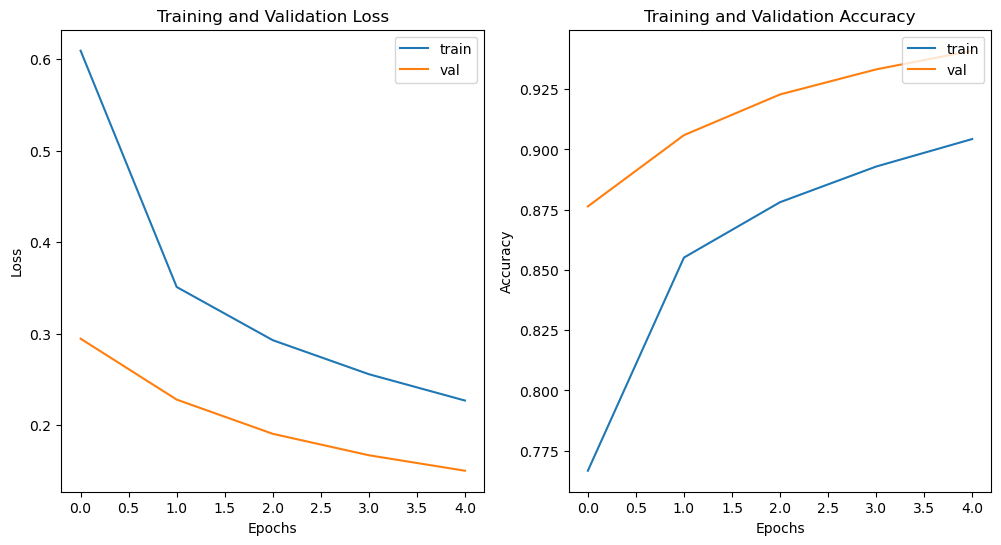

```python
loss_acc_plot(history8)
```

```python
training_accuracy8 = history8.history['accuracy'][-1]
training_loss8 = history8.history['loss'][-1]
print(f"Training Loss: {training_loss8:.4f}, Training Accuracy: {training_accuracy8:.4f}")
```

```
Training Loss: 0.2268, Training Accuracy: 0.9043
```

```python
val_loss8, val_accuracy8 = cnn_model8.evaluate(x_test,y_test)
print(f"Done!\nValiation Loss: {val_loss8:.4f}, Validation Accuracy: {val_accuracy8:.4f}")
```

```
Done!
Valiation Loss: 0.1500, Validation Accuracy: 0.9410
```

The training accuracy improved to 90.43%. From the graph above, the model doesn't seem to be overfitting. Let's use the model to predict the quiz to see how it performs.

```python
train_pred_8 = cnn_model8.predict(x_train[0].reshape((9, 9)).reshape(1, 9, 9, 1)).argmax(-1)+1
train_pred_8
```

```
array([[[8, 6, 4, 3, 7, 1, 2, 5, 9],
        [3, 2, 5, 8, 4, 9, 7, 6, 1],
        [8, 7, 1, 2, 6, 5, 8, 4, 3],
        [4, 3, 6, 1, 9, 2, 5, 8, 7],
        [1, 9, 8, 6, 5, 7, 4, 3, 2],
        [2, 5, 7, 4, 8, 3, 9, 1, 6],
        [6, 8, 9, 7, 3, 4, 1, 2, 5],
        [7, 1, 3, 5, 2, 8, 6, 9, 4],
        [5, 4, 2, 9, 1, 6, 3, 7, 8]]], dtype=int64)
```

```python
train_real_8 = y_train[0]+1
train_real_8
```

```
array([[8, 6, 4, 3, 7, 1, 2, 5, 9],
       [3, 2, 5, 8, 4, 9, 7, 6, 1],
       [9, 7, 1, 2, 6, 5, 8, 4, 3],
       [4, 3, 6, 1, 9, 2, 5, 8, 7],
       [1, 9, 8, 6, 5, 7, 4, 3, 2],
       [2, 5, 7, 4, 8, 3, 9, 1, 6],
       [6, 8, 9, 7, 3, 4, 1, 2, 5],
       [7, 1, 3, 5, 2, 8, 6, 9, 4],
       [5, 4, 2, 9, 1, 6, 3, 7, 8]])
```

```python
train_pred_8 - train_real_8
```

```
array([[[ 0,  0,  0,  0,  0,  0,  0,  0,  0],
        [ 0,  0,  0,  0,  0,  0,  0,  0,  0],
        [-1,  0,  0,  0,  0,  0,  0,  0,  0],
        [ 0,  0,  0,  0,  0,  0,  0,  0,  0],
        [ 0,  0,  0,  0,  0,  0,  0,  0,  0],
        [ 0,  0,  0,  0,  0,  0,  0,  0,  0],
        [ 0,  0,  0,  0,  0,  0,  0,  0,  0],
        [ 0,  0,  0,  0,  0,  0,  0,  0,  0],
        [ 0,  0,  0,  0,  0,  0,  0,  0,  0]]], dtype=int64)
```

There is one wrong prediction.

```python
test_pred_8 = cnn_model8.predict(x_test[1].reshape((9, 9)).reshape(1, 9, 9, 1)).argmax(-1)+1
test_pred_8
```

```
array([[[3, 1, 8, 4, 9, 2, 7, 5, 5],
        [7, 9, 6, 5, 1, 8, 2, 4, 3],
        [2, 5, 4, 3, 7, 6, 1, 8, 1],
        [8, 8, 9, 6, 4, 1, 5, 3, 7],
        [6, 7, 1, 2, 8, 5, 4, 9, 4],
        [5, 4, 3, 7, 3, 9, 6, 2, 8],
        [4, 3, 2, 8, 5, 7, 9, 1, 6],
        [1, 6, 5, 9, 2, 3, 8, 7, 4],
        [9, 6, 7, 1, 6, 4, 3, 5, 2]]], dtype=int64)
```

```python
test_real_8 = y_test[1]+1
test_real_8
```

```
array([[3, 1, 8, 4, 9, 2, 7, 6, 5],
       [7, 9, 6, 5, 1, 8, 2, 4, 3],
       [2, 5, 4, 3, 7, 6, 1, 8, 9],
       [8, 2, 9, 6, 4, 1, 5, 3, 7],
       [6, 7, 3, 2, 8, 5, 4, 9, 1],
       [5, 4, 1, 7, 3, 9, 6, 2, 8],
       [4, 3, 2, 8, 5, 7, 9, 1, 6],
       [1, 6, 5, 9, 2, 3, 8, 7, 4],
       [9, 8, 7, 1, 6, 4, 3, 5, 2]])
```

```python
test_pred_8 - test_real_8
```

```
array([[[ 0,  0,  0,  0,  0,  0,  0, -1,  0],
        [ 0,  0,  0,  0,  0,  0,  0,  0,  0],
        [ 0,  0,  0,  0,  0,  0,  0,  0, -8],
        [ 0,  6,  0,  0,  0,  0,  0,  0,  0],
        [ 0,  0, -2,  0,  0,  0,  0,  0,  3],
        [ 0,  0,  2,  0,  0,  0,  0,  0,  0],
        [ 0,  0,  0,  0,  0,  0,  0,  0,  0],
        [ 0,  0,  0,  0,  0,  0,  0,  0,  0],
        [ 0, -2,  0,  0,  0,  0,  0,  0,  0]]], dtype=int64)
```

There are 7 out of 81 wrong prediction on one of the testing quiz. This is not a good performance model.

#### CNN Model 9

Return to top

Let's build on top of the CNN Model 8 with strides of (3x3).

```python
# Function for the cnn model function
def cnn_model_func9():

    model = tf.keras.Sequential()

    model.add(Conv2D(512, kernel_size=(3,3), strides=(3,3), activation='relu', padding='same', input_shape=(9,9,1)))
    model.add(BatchNormalization())
    model.add(Conv2D(512, kernel_size=(3,3), strides=(3,3), activation='relu', padding='same'))
    model.add(BatchNormalization())
    model.add(Conv2D(512, kernel_size=(3,3), strides=(3,3), activation='relu', padding='same'))
    model.add(BatchNormalization())
    model.add(Conv2D(512, kernel_size=(3,3), strides=(3,3), activation='relu', padding='same'))
    model.add(BatchNormalization())
    model.add(Conv2D(512, kernel_size=(3,3), strides=(3,3), activation='relu', padding='same'))
    model.add(BatchNormalization())
    model.add(Conv2D(512, kernel_size=(3,3), strides=(3,3), activation='relu', padding='same'))
    model.add(Flatten())
    model.add(Dense(81*9))
    model.add(Dropout(0.1))
    model.add(tf.keras.layers.LayerNormalization(axis=-1))
    model.add(Reshape((9, 9, 9)))
    model.add(Activation('softmax'))

    return model
```

```python
# Initialise the cnn model
cnn_model9 = cnn_model_func9()
# print summary of the cnn model
cnn_model9.summary()
```

```
Model: "sequential_1"
_________________________________________________________________
 Layer (type)                Output Shape              Param #
=================================================================
 conv2d_18 (Conv2D)          (None, 3, 3, 512)         5120

 batch_normalization_17 (Bat  (None, 3, 3, 512)        2048
 chNormalization)

 conv2d_19 (Conv2D)          (None, 1, 1, 512)         2359808

 batch_normalization_18 (Bat  (None, 1, 1, 512)        2048
 chNormalization)

 conv2d_20 (Conv2D)          (None, 1, 1, 512)         2359808

 batch_normalization_19 (Bat  (None, 1, 1, 512)        2048
 chNormalization)

 conv2d_21 (Conv2D)          (None, 1, 1, 512)         2359808

 batch_normalization_20 (Bat  (None, 1, 1, 512)        2048
 chNormalization)

 conv2d_22 (Conv2D)          (None, 1, 1, 512)         2359808

 batch_normalization_21 (Bat  (None, 1, 1, 512)        2048
 chNormalization)

 conv2d_23 (Conv2D)          (None, 1, 1, 512)         2359808

 flatten_1 (Flatten)         (None, 512)               0

 dense_1 (Dense)             (None, 729)               373977

 dropout_1 (Dropout)         (None, 729)               0

 layer_normalization_1 (Laye  (None, 729)              1458
 rNormalization)

 reshape_1 (Reshape)         (None, 9, 9, 9)           0

 activation_1 (Activation)   (None, 9, 9, 9)           0

=================================================================
Total params: 12,189,835
Trainable params: 12,184,715
Non-trainable params: 5,120
_________________________________________________________________
```

```python
# Train the model
cnn_model9.compile(loss='sparse_categorical_crossentropy', optimizer=optimizer, metrics=['accuracy'])

history9 = cnn_model9.fit(x_train, y_train, batch_size=64, epochs=200, validation_data=(x_test, y_test))
```

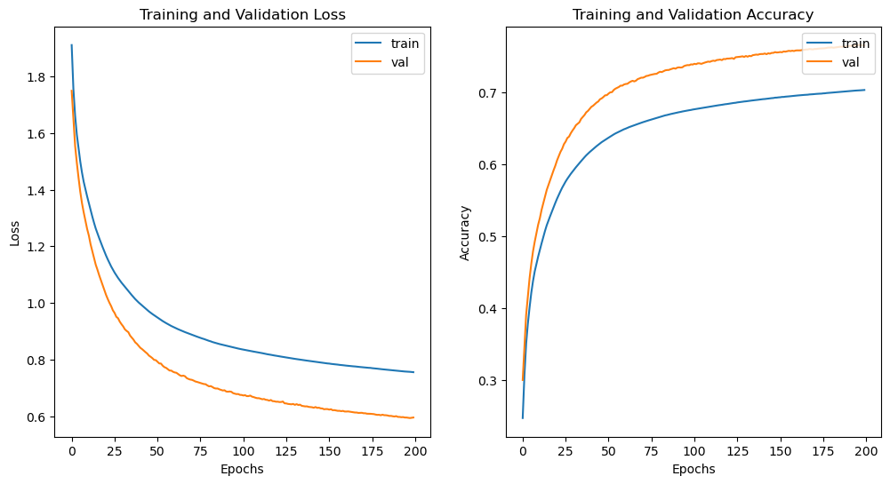

```python
loss_acc_plot(history9)
```

```python
training_accuracy9 = history9.history['accuracy'][-1]
training_loss9 = history9.history['loss'][-1]
print(f"Training Loss: {training_loss9:.4f}, Training Accuracy: {training_accuracy9:.4f}")
```

```
Training Loss: 0.7551, Training Accuracy: 0.7037
```

```python
val_loss9, val_accuracy9 = cnn_model9.evaluate(x_test,y_test)
print(f"Done!\nValiation Loss: {val_loss9:.4f}, Validation Accuracy: {val_accuracy9:.4f}")
```

```
Done!
Valiation Loss: 0.5950, Validation Accuracy: 0.7656
```

After 200 epochs, the training accuracy is only 70.37%. From the training above, we can see the accuracy is slowly increasing by 0.0002 for each epoch.

#### CNN Model 10

Return to top

Trying with 18 conv2D layer to see if it has a better performance.

```python
# Function for the cnn model function
def cnn_model_func10():

    model = tf.keras.Sequential()

    model.add(Conv2D(512, kernel_size=(3,3), strides=(3,3), activation='relu', padding='same', input_shape=(9,9,1)))
    model.add(BatchNormalization())
    model.add(Conv2D(512, kernel_size=(3,3), strides=(3,3), activation='relu', padding='same'))
    model.add(BatchNormalization())
    model.add(Conv2D(512, kernel_size=(3,3), strides=(3,3), activation='relu', padding='same'))
    model.add(BatchNormalization())
    model.add(Conv2D(512, kernel_size=(3,3), strides=(3,3), activation='relu', padding='same'))
    model.add(BatchNormalization())
    model.add(Conv2D(512, kernel_size=(3,3), strides=(3,3), activation='relu', padding='same'))
    model.add(BatchNormalization())
    model.add(Conv2D(512, kernel_size=(3,3), strides=(3,3), activation='relu', padding='same'))
    model.add(BatchNormalization())
    model.add(Conv2D(512, kernel_size=(3,3), strides=(3,3), activation='relu', padding='same'))
    model.add(BatchNormalization())
    model.add(Conv2D(512, kernel_size=(3,3), strides=(3,3), activation='relu', padding='same'))
    model.add(BatchNormalization())
    model.add(Conv2D(512, kernel_size=(3,3), strides=(3,3), activation='relu', padding='same'))
    model.add(BatchNormalization())
    model.add(Conv2D(512, kernel_size=(3,3), strides=(3,3), activation='relu', padding='same'))
    model.add(BatchNormalization())
    model.add(Conv2D(512, kernel_size=(3,3), strides=(3,3), activation='relu', padding='same'))
    model.add(BatchNormalization())
    model.add(Conv2D(512, kernel_size=(3,3), strides=(3,3), activation='relu', padding='same'))
    model.add(BatchNormalization())
    model.add(Conv2D(512, kernel_size=(3,3), strides=(3,3), activation='relu', padding='same'))
    model.add(BatchNormalization())
    model.add(Conv2D(512, kernel_size=(3,3), strides=(3,3), activation='relu', padding='same'))
    model.add(BatchNormalization())
    model.add(Conv2D(512, kernel_size=(3,3), strides=(3,3), activation='relu', padding='same'))
    model.add(BatchNormalization())
    model.add(Conv2D(512, kernel_size=(3,3), strides=(3,3), activation='relu', padding='same'))
    model.add(BatchNormalization())
    model.add(Conv2D(512, kernel_size=(3,3), strides=(3,3), activation='relu', padding='same'))
    model.add(BatchNormalization())
    model.add(Conv2D(512, kernel_size=(3,3), strides=(3,3), activation='relu', padding='same'))
    model.add(Flatten())
    model.add(Dense(81*9))
    model.add(Dropout(0.2))
    model.add(tf.keras.layers.LayerNormalization(axis=-1))
    model.add(Reshape((9, 9, 9)))
    model.add(Activation('softmax'))

    return model
```

```python
# Initialise the cnn model
cnn_model10 = cnn_model_func10()
# print summary of the cnn model
cnn_model10.summary()
```

```
Model: "sequential"
_________________________________________________________________
 Layer (type)                Output Shape              Param #
=================================================================
 conv2d (Conv2D)             (None, 3, 3, 512)         5120

 batch_normalization (BatchN  (None, 3, 3, 512)        2048
 ormalization)

 conv2d_1 (Conv2D)           (None, 1, 1, 512)         2359808

 batch_normalization_1 (Batc  (None, 1, 1, 512)        2048
 hNormalization)

 conv2d_2 (Conv2D)           (None, 1, 1, 512)         2359808

 batch_normalization_2 (Batc  (None, 1, 1, 512)        2048
 hNormalization)

 conv2d_3 (Conv2D)           (None, 1, 1, 512)         2359808

 batch_normalization_3 (Batc  (None, 1, 1, 512)        2048
 hNormalization)

 conv2d_4 (Conv2D)           (None, 1, 1, 512)         2359808

 batch_normalization_4 (Batc  (None, 1, 1, 512)        2048
 hNormalization)

 conv2d_5 (Conv2D)           (None, 1, 1, 512)         2359808

 batch_normalization_5 (Batc  (None, 1, 1, 512)        2048
 hNormalization)

 conv2d_6 (Conv2D)           (None, 1, 1, 512)         2359808

 batch_normalization_6 (Batc  (None, 1, 1, 512)        2048
 hNormalization)

 conv2d_7 (Conv2D)           (None, 1, 1, 512)         2359808
```

[output cut: 54 more lines]

```

 dropout (Dropout)           (None, 729)               0

 layer_normalization (LayerN  (None, 729)              1458
 ormalization)

 reshape (Reshape)           (None, 9, 9, 9)           0

 activation (Activation)     (None, 9, 9, 9)           0

=================================================================
Total params: 40,532,107
Trainable params: 40,514,699
Non-trainable params: 17,408
_________________________________________________________________
```

```python
# Train the model
cnn_model10.compile(loss='sparse_categorical_crossentropy', optimizer=optimizer, metrics=['accuracy'])

history10 = cnn_model10.fit(x_train, y_train, batch_size=64, epochs=100, validation_data=(x_test, y_test))
```

[output not shown]

[output cut: 65 more lines]

[output not shown]

After 63 epochs with about 6 hours of training, I interrupt the training by the keyboard. The training accuracy is only 19% with a slow increase. The training is incomplete.

#### CNN Model 11

Return to top

Testing with 9 conv2D layers, 9 is matching 9 numbers of Sudoku and the game board is 9 x 9.

```python
# Function for the cnn model function
def cnn_model_func11():

    model = tf.keras.Sequential()

    model.add(Conv2D(512, kernel_size=(3,3), activation='relu', padding='same', input_shape=(9,9,1)))
    model.add(BatchNormalization())
    model.add(Conv2D(512, kernel_size=(3,3), activation='relu', padding='same'))
    model.add(BatchNormalization())
    model.add(Conv2D(512, kernel_size=(3,3), activation='relu', padding='same'))
    model.add(BatchNormalization())
    model.add(Conv2D(512, kernel_size=(3,3), activation='relu', padding='same'))
    model.add(BatchNormalization())
    model.add(Conv2D(512, kernel_size=(3,3), activation='relu', padding='same'))
    model.add(BatchNormalization())
    model.add(Conv2D(512, kernel_size=(3,3), activation='relu', padding='same'))
    model.add(BatchNormalization())
    model.add(Conv2D(512, kernel_size=(3,3), activation='relu', padding='same'))
    model.add(BatchNormalization())
    model.add(Conv2D(512, kernel_size=(3,3), activation='relu', padding='same'))
    model.add(BatchNormalization())
    model.add(Conv2D(512, kernel_size=(3,3), activation='relu', padding='same'))
    model.add(Flatten())
    model.add(Dense(81*9))
    model.add(Dropout(0.1))
    model.add(tf.keras.layers.LayerNormalization(axis=-1))
    model.add(Reshape((9, 9, 9)))
    model.add(Activation('softmax'))

    return model
```

```python
# Initialise the cnn model
cnn_model11 = cnn_model_func11()
# print summary of the cnn model
cnn_model11.summary()
```

```
Model: "sequential"
_________________________________________________________________
 Layer (type)                Output Shape              Param #
=================================================================
 conv2d (Conv2D)             (None, 9, 9, 512)         5120

 batch_normalization (BatchN  (None, 9, 9, 512)        2048
 ormalization)

 conv2d_1 (Conv2D)           (None, 9, 9, 512)         2359808

 batch_normalization_1 (Batc  (None, 9, 9, 512)        2048
 hNormalization)

 conv2d_2 (Conv2D)           (None, 9, 9, 512)         2359808

 batch_normalization_2 (Batc  (None, 9, 9, 512)        2048
 hNormalization)

 conv2d_3 (Conv2D)           (None, 9, 9, 512)         2359808

 batch_normalization_3 (Batc  (None, 9, 9, 512)        2048
 hNormalization)

 conv2d_4 (Conv2D)           (None, 9, 9, 512)         2359808

 batch_normalization_4 (Batc  (None, 9, 9, 512)        2048
 hNormalization)

 conv2d_5 (Conv2D)           (None, 9, 9, 512)         2359808

 batch_normalization_5 (Batc  (None, 9, 9, 512)        2048
 hNormalization)

 conv2d_6 (Conv2D)           (None, 9, 9, 512)         2359808

 batch_normalization_6 (Batc  (None, 9, 9, 512)        2048
 hNormalization)

 conv2d_7 (Conv2D)           (None, 9, 9, 512)         2359808
```

[output cut: 9 more lines]

```

 dropout (Dropout)           (None, 729)               0

 layer_normalization (LayerN  (None, 729)              1458
 ormalization)

 reshape (Reshape)           (None, 9, 9, 9)           0

 activation (Activation)     (None, 9, 9, 9)           0

=================================================================
Total params: 49,135,243
Trainable params: 49,127,051
Non-trainable params: 8,192
_________________________________________________________________
```

```python
# Train the model
cnn_model11.compile(loss='sparse_categorical_crossentropy', optimizer=optimizer, metrics=['accuracy'])

history11 = cnn_model11.fit(x_train, y_train, batch_size=64, epochs=5, validation_data=(x_test, y_test))
```

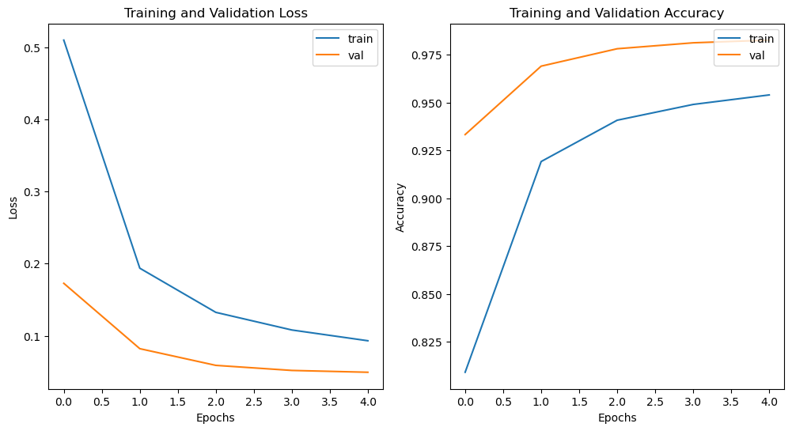

```python
loss_acc_plot(history11)
```

```python
training_accuracy11 = history11.history['accuracy'][-1]
training_loss11 = history11.history['loss'][-1]
print(f"Training Loss: {training_loss11:.4f}, Training Accuracy: {training_accuracy11:.4f}")
```

```
Training Loss: 0.0930, Training Accuracy: 0.9540
```

```python
val_loss11, val_accuracy11 = cnn_model11.evaluate(x_test,y_test)
print(f"Done!\nValiation Loss: {val_loss11:.4f}, Validation Accuracy: {val_accuracy11:.4f}")
```

```
Done!
Valiation Loss: 0.0493, Validation Accuracy: 0.9827
```

After only five epochs, the model has a 95.4% training accuracy. The model performance is desirable.

### Discussion

Return to top

Let's create a summary table with for each model.

[output not shown]

The convolution neural networks (CNN) is good at extracting features. An increase in the number of epochs, number of layers, and number of neurons per layer can help improve the accuracy of the model. In this project, we start with a simple CNN model with 3 conv2D layers. The model is overfitting. So we have tried adding a dropout layer or using maxpooling to prevent overfitting. Adding strides of (3x3) could be good considering valid sudoku must follow each of the nine 3X3 sub-squares and should contain 1-9 digits without repetition. However, models that have strides require longer training hours with more epochs.

After testing all of the models, the **cnn_model_11** has the best performance in solving sudoku games with a training accuracy of 0.9540 and validation accuracy of 0.9827.

Let's test the model to see whether it can solve a real sudoku game or not.

```python
train_pred_11 = cnn_model11.predict(x_train[0].reshape((9, 9)).reshape(1, 9, 9, 1)).argmax(-1)+1
train_pred_11
```

```
array([[[8, 6, 4, 3, 7, 1, 2, 5, 9],
        [3, 2, 5, 8, 4, 9, 7, 6, 1],
        [9, 7, 1, 2, 6, 5, 8, 4, 3],
        [4, 3, 6, 1, 9, 2, 5, 8, 7],
        [1, 9, 8, 6, 5, 7, 4, 3, 2],
        [2, 5, 7, 4, 8, 3, 9, 1, 6],
        [6, 8, 9, 7, 3, 4, 1, 2, 5],
        [7, 1, 3, 5, 2, 8, 6, 9, 4],
        [5, 4, 2, 9, 1, 6, 3, 7, 8]]], dtype=int64)
```

```python
train_real_11 = y_train[0]+1
train_real_11
```

```
array([[8, 6, 4, 3, 7, 1, 2, 5, 9],
       [3, 2, 5, 8, 4, 9, 7, 6, 1],
       [9, 7, 1, 2, 6, 5, 8, 4, 3],
       [4, 3, 6, 1, 9, 2, 5, 8, 7],
       [1, 9, 8, 6, 5, 7, 4, 3, 2],
       [2, 5, 7, 4, 8, 3, 9, 1, 6],
       [6, 8, 9, 7, 3, 4, 1, 2, 5],
       [7, 1, 3, 5, 2, 8, 6, 9, 4],
       [5, 4, 2, 9, 1, 6, 3, 7, 8]])
```

```python
train_pred_11 - train_real_11
```

```
array([[[0, 0, 0, 0, 0, 0, 0, 0, 0],
        [0, 0, 0, 0, 0, 0, 0, 0, 0],
        [0, 0, 0, 0, 0, 0, 0, 0, 0],
        [0, 0, 0, 0, 0, 0, 0, 0, 0],
        [0, 0, 0, 0, 0, 0, 0, 0, 0],
        [0, 0, 0, 0, 0, 0, 0, 0, 0],
        [0, 0, 0, 0, 0, 0, 0, 0, 0],
        [0, 0, 0, 0, 0, 0, 0, 0, 0],
        [0, 0, 0, 0, 0, 0, 0, 0, 0]]], dtype=int64)
```

There are all zeros means the model is predicting all 81 numbers correctly!  
Let's test it with one of the quizzes from the testing set, which the model hasn't seem before.

```python
test_pred_11 = cnn_model11.predict(x_test[1].reshape((9, 9)).reshape(1, 9, 9, 1)).argmax(-1)+1
test_pred_11
```

```
array([[[3, 1, 8, 4, 9, 2, 7, 6, 5],
        [7, 9, 6, 5, 1, 8, 2, 4, 3],
        [2, 5, 4, 3, 7, 6, 1, 8, 9],
        [8, 2, 9, 6, 4, 1, 5, 3, 7],
        [6, 7, 3, 2, 8, 5, 4, 9, 1],
        [5, 4, 1, 7, 3, 9, 6, 2, 8],
        [4, 3, 2, 8, 5, 7, 9, 1, 6],
        [1, 6, 5, 9, 2, 3, 8, 7, 4],
        [9, 8, 7, 1, 6, 4, 3, 5, 2]]], dtype=int64)
```

```python
test_real_11 = y_test[1]+1
test_real_11
```

```
array([[3, 1, 8, 4, 9, 2, 7, 6, 5],
       [7, 9, 6, 5, 1, 8, 2, 4, 3],
       [2, 5, 4, 3, 7, 6, 1, 8, 9],
       [8, 2, 9, 6, 4, 1, 5, 3, 7],
       [6, 7, 3, 2, 8, 5, 4, 9, 1],
       [5, 4, 1, 7, 3, 9, 6, 2, 8],
       [4, 3, 2, 8, 5, 7, 9, 1, 6],
       [1, 6, 5, 9, 2, 3, 8, 7, 4],
       [9, 8, 7, 1, 6, 4, 3, 5, 2]])
```

```python
test_pred_11 - test_real_11
```

```
array([[[0, 0, 0, 0, 0, 0, 0, 0, 0],
        [0, 0, 0, 0, 0, 0, 0, 0, 0],
        [0, 0, 0, 0, 0, 0, 0, 0, 0],
        [0, 0, 0, 0, 0, 0, 0, 0, 0],
        [0, 0, 0, 0, 0, 0, 0, 0, 0],
        [0, 0, 0, 0, 0, 0, 0, 0, 0],
        [0, 0, 0, 0, 0, 0, 0, 0, 0],
        [0, 0, 0, 0, 0, 0, 0, 0, 0],
        [0, 0, 0, 0, 0, 0, 0, 0, 0]]], dtype=int64)
```

There are all zeros means the model is predicting all 81 numbers correctly!

#### Confunsion matrix

Use the model to make predict all the testing data.

```python
y_pred_11 = cnn_model11.predict(x_test)
```

Since we used normalization to transform the dataset before, we need to create functions to transform the prediction and the testing data back to the real board game with a dimension of (200000, 2).

```python
def y_pred_func(len, model):
    list = []
    for i in range(len):
        test_pred = model.predict(x_test[i].reshape((9, 9)).reshape(1, 9, 9, 1)).argmax(-1)+1
        list.append((i, test_pred))
    return np.array(list)
```

```python
y_pred_11 = y_pred_func(x_test.shape[0], cnn_model11)
```

```python
print(y_pred_11[0])
```

```
[0 array([[[4, 9, 7, 3, 2, 5, 6, 8, 1],
           [3, 1, 2, 8, 7, 6, 5, 9, 4],
           [5, 6, 8, 9, 1, 4, 3, 7, 2],
           [9, 8, 4, 6, 3, 2, 1, 5, 7],
           [1, 5, 6, 7, 4, 8, 9, 2, 3],
           [7, 2, 3, 5, 9, 1, 4, 6, 8],
           [6, 3, 1, 2, 8, 9, 7, 4, 5],
           [8, 7, 5, 4, 6, 3, 2, 1, 9],
           [2, 4, 9, 1, 5, 7, 8, 3, 6]]], dtype=int64)]
```

```python
y_pred_11.shape
```

```
(200000, 2)
```

```python
def y_real_func(data):
    len = data.shape[0]
    list = []
    for i in range(len):
        y_real = data[i] +1
        list.append((i, y_real))
    return np.array(list)
```

```python
y_real_11 = y_real_func(y_test)
```

```python
y_real_11.shape
```

```
(200000, 2)
```

```python
y_real_11[0][1]
```

```
array([[4, 9, 7, 3, 2, 5, 6, 8, 1],
       [3, 1, 2, 8, 7, 6, 5, 9, 4],
       [5, 6, 8, 9, 1, 4, 3, 7, 2],
       [9, 8, 4, 6, 3, 2, 1, 5, 7],
       [1, 5, 6, 7, 4, 8, 9, 2, 3],
       [7, 2, 3, 5, 9, 1, 4, 6, 8],
       [6, 3, 1, 2, 8, 9, 7, 4, 5],
       [8, 7, 5, 4, 6, 3, 2, 1, 9],
       [2, 4, 9, 1, 5, 7, 8, 3, 6]])
```

```python
y_pred_11[0][1][0]
```

```
array([[4, 9, 7, 3, 2, 5, 6, 8, 1],
       [3, 1, 2, 8, 7, 6, 5, 9, 4],
       [5, 6, 8, 9, 1, 4, 3, 7, 2],
       [9, 8, 4, 6, 3, 2, 1, 5, 7],
       [1, 5, 6, 7, 4, 8, 9, 2, 3],
       [7, 2, 3, 5, 9, 1, 4, 6, 8],
       [6, 3, 1, 2, 8, 9, 7, 4, 5],
       [8, 7, 5, 4, 6, 3, 2, 1, 9],
       [2, 4, 9, 1, 5, 7, 8, 3, 6]], dtype=int64)
```

Create a function to calculate the accuracy for each position.

```python
def count_grid_acc(actual, predicted):
    result = np.zeros((9,9), dtype=np.int)
    for i in range(y_real_11.shape[0]):
        for j in range(9):
            for k in range(9):
                if actual[i][1][j][k] == predicted[i][1][0][j][k]:
                    result[j][k] += 1
    return result
```

```python
cga = count_grid_acc(y_real_11, y_pred_11)
```

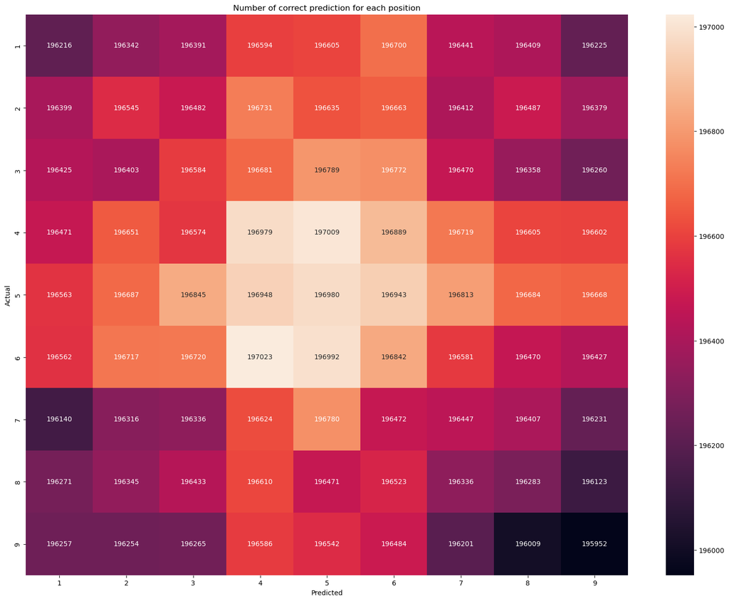

```python
ticks = [1,2,3,4,5,6,7,8,9]

plt.figure(figsize=(20,15))
sns.heatmap(cga, annot=True, fmt='g',xticklabels = ticks, yticklabels = ticks)
plt.title('Number of correct prediction for each position')
plt.xlabel('Predicted')
plt.ylabel('Actual')
```

It looks like for each position, the model makes the correct prediction of about 196,500 out of 200,000. It looks pretty high, let's build a function to check the accuracy for each position.

```python
def count_grid_position_acc(cga):
    sum = y_test.shape[0]
    acc = np.zeros((9,9))
    for i in range(9):
        for j in range(9):
            acc[i][j] = round(cga[i][j] / sum, 4)
    return acc
```

```python
cga_acc = count_grid_position_acc(cga)
```

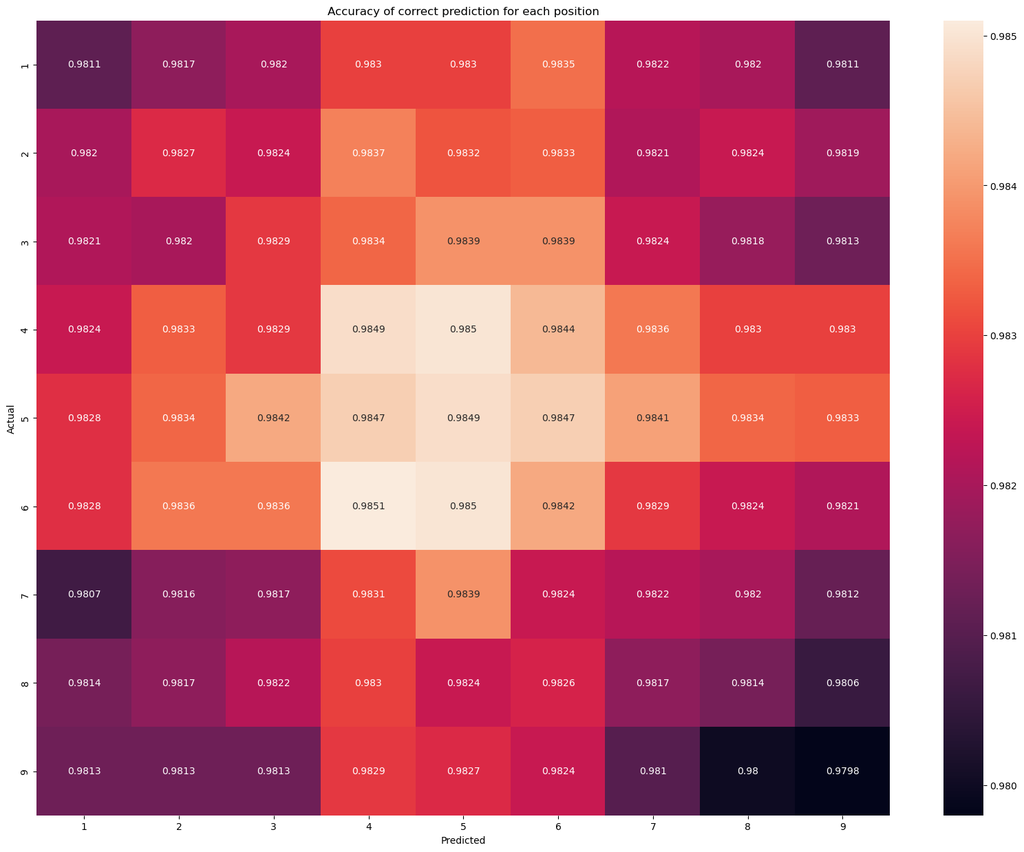

```python
ticks = [1,2,3,4,5,6,7,8,9]

plt.figure(figsize=(20,15))
sns.heatmap(cga_acc, annot=True, fmt='g',xticklabels = ticks, yticklabels = ticks)
plt.title('Accuracy of correct prediction for each position')
plt.xlabel('Predicted')
plt.ylabel('Actual')
```

Looks like all positions are around 98% correct.

Let's build a confusion matrix function to evaluate the model. The **confusion matrix** is a summary of prediction results for a classification problem. We want to evaluate to check if the model can classify the digit 1 to 9 correctly.

```python
def confusion_matrix_func(actual, predicted):
    result = np.zeros((9,9), dtype=np.int)
    for i in range(y_real_11.shape[0]):
        for j in range(9):
            for k in range(9):
                if predicted[i][1][0][j][k] == actual[i][1][j][k]:
                    result[actual[i][1][j][k]-1][actual[i][1][j][k]-1] += 1
                else:
                    result[actual[i][1][j][k]-1][predicted[i][1][0][j][k]-1] += 1
    return result
```

```python
cm = confusion_matrix_func(y_real_11, y_pred_11)
```

```python
cm
```

```
array([[1767456,    4197,    3986,    4217,    4448,    4081,    3857,
           3983,    3775],
       [   3863, 1769048,    3762,    4067,    4135,    3932,    3871,
           3740,    3582],
       [   3741,    4121, 1768841,    4049,    4057,    3970,    3750,
           3817,    3654],
       [   3958,    4046,    3778, 1769192,    4181,    3814,    3814,
           3691,    3526],
       [   4029,    4329,    4013,    4305, 1767418,    4002,    4040,
           3995,    3869],
       [   4098,    4223,    3987,    4261,    4377, 1767346,    3985,
           4079,    3644],
       [   3870,    4097,    3868,    4080,    4371,    3898, 1768543,
           3767,    3506],
       [   3660,    3710,    3635,    3925,    3913,    3680,    3686,
        1770314,    3477],
       [   3555,    3777,    3502,    3788,    3854,    3675,    3525,
           3422, 1770902]])
```

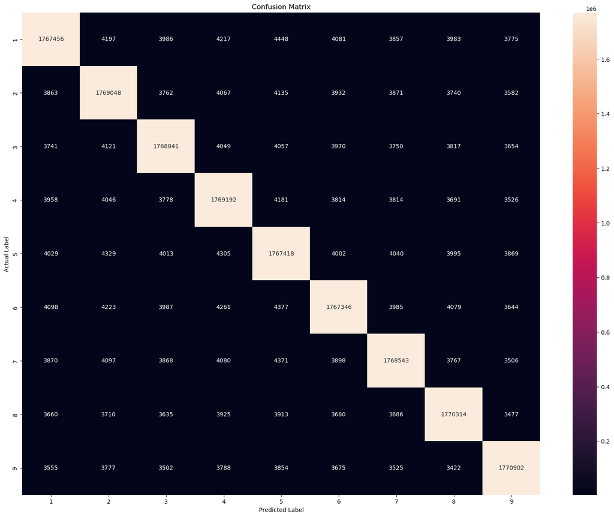

```python
plt.figure(figsize=(20,15))
sns.heatmap(cm, annot=True, fmt='d',xticklabels = ticks, yticklabels = ticks)
plt.title('Confusion Matrix')
plt.xlabel('Predicted Label')
plt.ylabel('Actual Label')
```

The y-axis is the actual label and the x-axis is the predicted label. For example, the first number 1,767,456 indicates that the model predicts the number is 1 when it is actually one. This is also called a true positive. However, the second of the first row indicates the model predicts 4197 times that the digit is 2 but it is actually 1. This is also called False Negative. The first number of the second row indicates the model predicts 3863 times that the digit is 1 but it is actually 2.

Let's normalize the confusion matrix to have a better idea of how it performs.

```python
norm_cm = np.round(cm/cm.astype(np.float).sum(axis=1), 4)
```

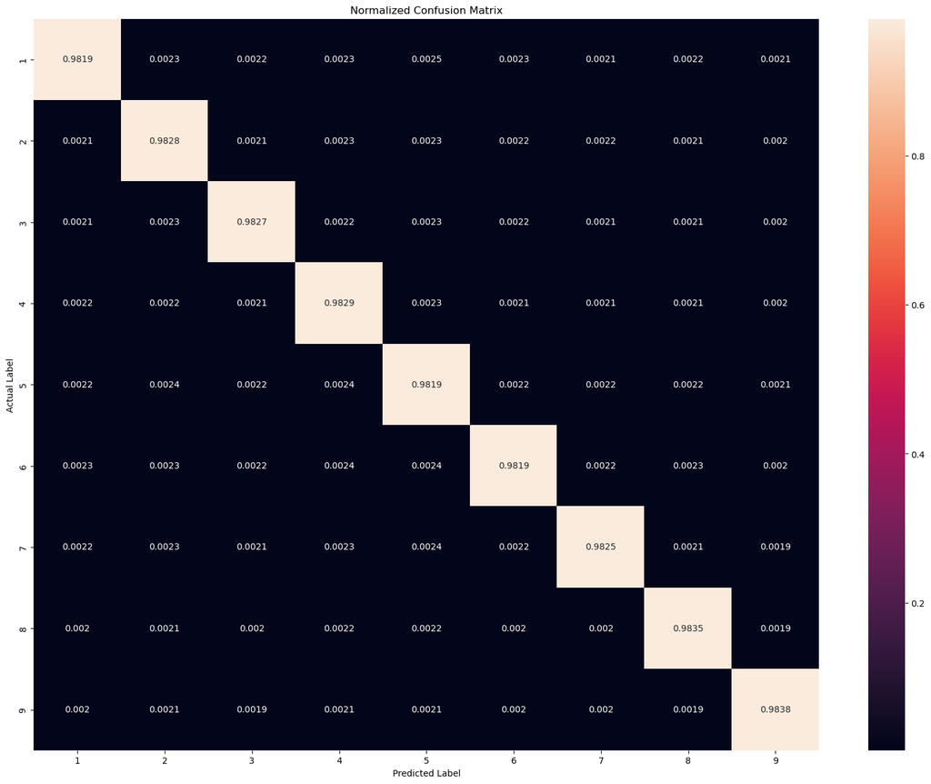

```python
plt.figure(figsize=(20,15))
sns.heatmap(norm_cm, annot=True, fmt='g',xticklabels = ticks, yticklabels = ticks)
plt.title('Normalized Confusion Matrix')
plt.xlabel('Predicted Label')
plt.ylabel('Actual Label')
```

We can see there are around 98% of times the model predicts the digit is 1 when it is actually 1.

```python
df = pd.DataFrame(cm, index= ['1','2','3','4','5','6','7','8','9'], columns=['1','2','3','4','5','6','7','8','9'], dtype=int)
df.da.export_metrics()
```

|  | 1 | 2 | 3 | 4 | 5 | 6 | 7 | 8 | 9 | micro-average |
| --- | --- | --- | --- | --- | --- | --- | --- | --- | --- | --- |
| accuracy | 0.996091 | 0.996083 | 0.996192 | 0.996080 | 0.995931 | 0.996068 | 0.996174 | 0.996285 | 0.996412 | 0.996146 |
| f1 | 0.982403 | 0.982382 | 0.982861 | 0.982370 | 0.981693 | 0.982296 | 0.982778 | 0.983287 | 0.983852 | 0.982658 |
| false_discovery_rate | 0.017113 | 0.018040 | 0.016968 | 0.018143 | 0.018512 | 0.017266 | 0.016969 | 0.016934 | 0.016130 | 0.017342 |
| false_negative_rate | 0.018080 | 0.017196 | 0.017311 | 0.017116 | 0.018101 | 0.018141 | 0.017476 | 0.016492 | 0.016166 | 0.017342 |
| false_positive_rate | 0.002137 | 0.002257 | 0.002120 | 0.002270 | 0.002315 | 0.002156 | 0.002120 | 0.002118 | 0.002016 | 0.002168 |
| negative_predictive_value | 0.997740 | 0.997850 | 0.997836 | 0.997860 | 0.997737 | 0.997733 | 0.997816 | 0.997938 | 0.997979 | 0.997832 |
| positive_predictive_value | 0.982887 | 0.981960 | 0.983032 | 0.981857 | 0.981488 | 0.982734 | 0.983031 | 0.983066 | 0.983870 | 0.982658 |
| precision | 0.982887 | 0.981960 | 0.983032 | 0.981857 | 0.981488 | 0.982734 | 0.983031 | 0.983066 | 0.983870 | 0.982658 |
| recall | 0.981920 | 0.982804 | 0.982689 | 0.982884 | 0.981899 | 0.981859 | 0.982524 | 0.983508 | 0.983834 | 0.982658 |
| sensitivity | 0.981920 | 0.982804 | 0.982689 | 0.982884 | 0.981899 | 0.981859 | 0.982524 | 0.983508 | 0.983834 | 0.982658 |
| specificity | 0.997863 | 0.997743 | 0.997880 | 0.997730 | 0.997685 | 0.997844 | 0.997880 | 0.997882 | 0.997984 | 0.997832 |
| true_negative_rate | 0.997863 | 0.997743 | 0.997880 | 0.997730 | 0.997685 | 0.997844 | 0.997880 | 0.997882 | 0.997984 | 0.997832 |
| true_positive_rate | 0.981920 | 0.982804 | 0.982689 | 0.982884 | 0.981899 | 0.981859 | 0.982524 | 0.983508 | 0.983834 | 0.982658 |

From the report above, we can see the average f1 score is 98% for this model. The F1 score encodes precision and recall. The score is high indicating the model is well performed.

### Conclusion

In this study, we have experimented with different neural networks such as CNN. The above study has shown the possibility of solving sudoku games using Deep learning methods. The neural networks have better performance with zero-centred normalized data. The data have been divided by 9 and subtracted by 0.5 to achieve zero mean-centred data. The convolution neural networks (CNN) is good at extracting features. An increase in the number of epochs, number of layers, and number of neurons per layer can help improve the accuracy of the model. Dropout layer or maxpooling can help prevent overfitting. Adding strides of 3 x 3 could be useful but require large training hours and computing power.

From the above experiments with different neural network models, the CNN model is able to solve a sudoku game but may still make some mistakes in the game. The cnn_model_11 is the optimal choice for model selection. The model includes 9 convolution layers with 512 kernels. A dropout layer of 0.1 was added to the model to prevent overfitting. After 5 epochs, the model generates a 95% of training accuracy. For each grid on the sudoku game board, the model is able to predict 98% correctly on unseen data. The model is also doing a great job to predict the digits 1 to 9 correctly. Overall, a CNN model with a certain number of convolution layers and a large number of neurons should be able to predict a classical sudoku game.

Return to top